# NBA Clustering Project

Mike Kaminski

2022-05-29

# Libraries

- library(data.table)
- library(dplyr)
- library(factoextra)
- library(gghighlight)
- library(ggplot2)
- library(psych)
- library(readr)
- library(readxl)
- library(stringi)
- library(stringr)
- library(tidyr)

# Import Files

- Data was scraped from [https://www.basketball-reference.com/] using Python and .csv files were saved
- Columns: blank columns need to be removed, columns containing ‘%’ need to be renamed to ‘PCT’, columns containing ‘2’ or ‘3’ will be renamed to include ‘Two’ and ‘Thr’, and periods will be replaced by underscores

### Per 100 possessions

- G, GS, MP, FG_PCT, ThrP_PCT, FT_PCT are not per 100 possessions, they are season totals

```r
per_poss <- read_csv("per_poss.csv")
colnames(per_poss)
```

```
##  [1] "Rk"          "Player"      "Pos"         "Age"         "Tm"
##  [6] "G"           "GS"          "MP"          "FG"          "FGA"
## [11] "FG PCT"      "3P"          "3PA"         "3P PCT"      "2P"
## [16] "2PA"         "2P PCT"      "FT"          "FTA"         "FT PCT"
## [21] "ORB"         "DRB"         "TRB"         "AST"         "STL"
## [26] "BLK"         "TOV"         "PF"          "PTS"         "Unnamed: 29"
## [31] "ORtg"        "DRtg"        "Year"
```

```r
per_poss1 <- subset(per_poss) %>%
  select('Year', everything()) %>%
  select(-c(contains('Unnamed'))) %>%
  rename_at(vars(contains("%")),funs(str_replace_all(., "%","_PCT"))) %>%
  rename_at(vars(contains("3")),funs(str_replace(., "3","Thr"))) %>%
  rename_at(vars(contains("2")),funs(str_replace(., "2","Two"))) %>%
  rename_at(vars(contains(" ")),funs(str_replace_all(., " ","_")))
head(per_poss1)
```

```
## # A tibble: 6 × 32
##    Year    Rk Player      Pos     Age Tm        G    GS    MP    FG   FGA FG_PCT
##   <dbl> <dbl> <chr>       <chr> <dbl> <chr> <dbl> <dbl> <dbl> <dbl> <dbl>  <dbl>
## 1  2001     1 Mahmoud Ab… PG       31 VAN      41     0   486  12.9  26.5  0.488
## 2  2001     2 Tariq Abdu… SG       26 DEN      29    12   420   5.3  13.7  0.387
## 3  2001     3 Shareef Ab… SF       24 VAN      81    81  3241   9.8  20.7  0.472
## 4  2001     4 Cory Alexa… PG       27 ORL      26     0   227   4.1  12.7  0.321
## 5  2001     5 Courtney A… PG       23 TOT      65    24  1382   8.9  21.4  0.417
## 6  2001     5 Courtney A… PG       23 DAL      38     6   472   6.8  19.4  0.348
## # … with 20 more variables: ThrP <dbl>, ThrPA <dbl>, ThrP_PCT <dbl>,
## #   TwoP <dbl>, TwoPA <dbl>, TwoP_PCT <dbl>, FT <dbl>, FTA <dbl>, FT_PCT <dbl>,
## #   ORB <dbl>, DRB <dbl>, TRB <dbl>, AST <dbl>, STL <dbl>, BLK <dbl>,
## #   TOV <dbl>, PF <dbl>, PTS <dbl>, ORtg <dbl>, DRtg <dbl>
```

```r
colnames(per_poss1)
```

```
##  [1] "Year"     "Rk"       "Player"   "Pos"      "Age"      "Tm"
##  [7] "G"        "GS"       "MP"       "FG"       "FGA"      "FG_PCT"
## [13] "ThrP"     "ThrPA"    "ThrP_PCT" "TwoP"     "TwoPA"    "TwoP_PCT"
## [19] "FT"       "FTA"      "FT_PCT"   "ORB"      "DRB"      "TRB"
## [25] "AST"      "STL"      "BLK"      "TOV"      "PF"       "PTS"
## [31] "ORtg"     "DRtg"
```

### Advanced

```r
adv <- read_csv("advanced.csv")
colnames(adv)
```

```
##  [1] "Rk"          "Player"      "Pos"         "Age"         "Tm"
##  [6] "G"           "MP"          "PER"         "TS%"         "3PAr"
## [11] "FTr"         "ORB PCT"     "DRB PCT"     "TRB PCT"     "AST PCT"
## [16] "STL PCT"     "BLK PCT"     "TOV PCT"     "USG PCT"     "Unnamed: 19"
## [21] "OWS"         "DWS"         "WS"          "WS per 48"   "Unnamed: 24"
## [26] "OBPM"        "DBPM"        "BPM"         "VORP"        "Year"
```

```r
adv1 <- subset(adv) %>%
  select('Year', everything()) %>%
  select(-c(contains('Unnamed'))) %>%
  rename_at(vars(contains("%")),funs(str_replace_all(., "%","_PCT"))) %>%
  rename_at(vars(contains("3")),funs(str_replace(., "3","Thr"))) %>%
  rename_at(vars(contains("2")),funs(str_replace(., "2","Two"))) %>%
  rename_at(vars(contains(" ")),funs(str_replace_all(., " ","_")))
head(adv1)
```

```
## # A tibble: 6 × 28
##    Year    Rk Player     Pos     Age Tm        G    MP   PER TS_PCT ThrPAr   FTr
##   <dbl> <dbl> <chr>      <chr> <dbl> <chr> <dbl> <dbl> <dbl>  <dbl>  <dbl> <dbl>
## 1  2001     1 Mahmoud A… PG       31 VAN      41   486  16.7  0.514  0.057 0.118
## 2  2001     2 Tariq Abd… SG       26 DEN      29   420   5.8  0.438  0.09  0.324
## 3  2001     3 Shareef A… SF       24 VAN      81  3241  19.1  0.549  0.05  0.415
## 4  2001     4 Cory Alex… PG       27 ORL      26   227   6.3  0.407  0.286 0.321
## 5  2001     5 Courtney … PG       23 TOT      65  1382  11.6  0.484  0.08  0.262
## 6  2001     5 Courtney … PG       23 DAL      38   472   6.8  0.404  0.056 0.253
## # … with 16 more variables: ORB_PCT <dbl>, DRB_PCT <dbl>, TRB_PCT <dbl>,
## #   AST_PCT <dbl>, STL_PCT <dbl>, BLK_PCT <dbl>, TOV_PCT <dbl>, USG_PCT <dbl>,
## #   OWS <dbl>, DWS <dbl>, WS <dbl>, WS_per_48 <dbl>, OBPM <dbl>, DBPM <dbl>,
## #   BPM <dbl>, VORP <dbl>
```

```r
colnames(adv1)
```

```
##  [1] "Year"      "Rk"        "Player"    "Pos"       "Age"       "Tm"
##  [7] "G"         "MP"        "PER"       "TS_PCT"    "ThrPAr"    "FTr"
## [13] "ORB_PCT"   "DRB_PCT"   "TRB_PCT"   "AST_PCT"   "STL_PCT"   "BLK_PCT"
## [19] "TOV_PCT"   "USG_PCT"   "OWS"       "DWS"       "WS"        "WS_per_48"
## [25] "OBPM"      "DBPM"      "BPM"       "VORP"
```

### Shooting

```r
shoot <- read_csv("shooting.csv")
colnames(shoot)
```

```
##  [1] "Rk"                           "Player"
##  [3] "Pos"                          "Age"
##  [5] "Tm"                           "G"
##  [7] "MP"                           "FG PCT"
##  [9] "Dist."                        "Unnamed: 9_level_1"
## [11] "PCT of FGA by Distance 2P"    "PCT of FGA by Distance 0-3"
## [13] "PCT of FGA by Distance 3-10"  "PCT of FGA by Distance 10-16"
## [15] "PCT of FGA by Distance 16-3P" "PCT of FGA by Distance 3P"
## [17] "Unnamed: 16_level_1"          "FG PCT by Distance 2P"
## [19] "FG PCT by Distance 0-3"       "FG PCT by Distance 3-10"
## [21] "FG PCT by Distance 10-16"     "FG PCT by Distance 16-3P"
## [23] "FG PCT by Distance 3P"        "Unnamed: 23_level_1"
## [25] "PCT of FG Astd 2P"            "PCT of FG Astd 3P"
## [27] "Unnamed: 26_level_1"          "Dunks PCT FGA"
## [29] "Dunks"                        "Unnamed: 29_level_1"
## [31] "Corner 3s PCT 3PA"            "Corner 3s PCT 3P"
## [33] "Unnamed: 32_level_1"          "Heave Att"
## [35] "Heaves Comp"                  "Year"
```

```r
shoot1 <- subset(shoot) %>%
  select(-c(contains('Unnamed'))) %>%
  select('Year', everything()) %>%
  rename_at(vars(contains(" ")),funs(str_replace_all(., " ","_"))) %>%
  rename_at(vars(contains("_of")),funs(str_replace_all(., "_of",""))) %>%
  rename_at(vars(contains("_by")),funs(str_replace_all(., "_by",""))) %>%
  rename_at(vars(contains("Distance")),funs(str_replace(., "Distance","Dis"))) %>%
  rename_at(vars(contains("-")),funs(str_replace(., "-","_"))) %>%
  rename(Avg_Dist_FGA = Dist.)

head(shoot1)
```

```
## # A tibble: 6 × 30
##    Year    Rk Player           Pos     Age Tm        G    MP FG_PCT Avg_Dist_FGA
##   <dbl> <dbl> <chr>            <chr> <dbl> <chr> <dbl> <dbl>  <dbl>        <dbl>
## 1  2001     1 Mahmoud Abdul-R… PG       31 VAN      41   486  0.488         17.7
## 2  2001     2 Tariq Abdul-Wah… SG       26 DEN      29   420  0.387         11.4
## 3  2001     3 Shareef Abdur-R… SF       24 VAN      81  3241  0.472         10.1
## 4  2001     4 Cory Alexander   PG       27 ORL      26   227  0.321         16.8
## 5  2001     5 Courtney Alexan… PG       23 TOT      65  1382  0.417         13.6
## 6  2001     5 Courtney Alexan… PG       23 DAL      38   472  0.348         12.3
## # … with 20 more variables: PCT_FGA_Dis_2P <dbl>, PCT_FGA_Dis_0_3 <dbl>,
## #   PCT_FGA_Dis_3_10 <dbl>, PCT_FGA_Dis_10_16 <dbl>, PCT_FGA_Dis_16_3P <dbl>,
## #   PCT_FGA_Dis_3P <dbl>, FG_PCT_Dis_2P <dbl>, FG_PCT_Dis_0_3 <dbl>,
## #   FG_PCT_Dis_3_10 <dbl>, FG_PCT_Dis_10_16 <dbl>, FG_PCT_Dis_16_3P <dbl>,
## #   FG_PCT_Dis_3P <dbl>, PCT_FG_Astd_2P <dbl>, PCT_FG_Astd_3P <dbl>,
## #   Dunks_PCT_FGA <dbl>, Dunks <dbl>, Corner_3s_PCT_3PA <dbl>,
## #   Corner_3s_PCT_3P <dbl>, Heave_Att <dbl>, Heaves_Comp <dbl>
```

```r
colnames(shoot1)
```

```
##  [1] "Year"              "Rk"                "Player"
##  [4] "Pos"               "Age"               "Tm"
##  [7] "G"                 "MP"                "FG_PCT"
## [10] "Avg_Dist_FGA"      "PCT_FGA_Dis_2P"    "PCT_FGA_Dis_0_3"
## [13] "PCT_FGA_Dis_3_10"  "PCT_FGA_Dis_10_16" "PCT_FGA_Dis_16_3P"
## [16] "PCT_FGA_Dis_3P"    "FG_PCT_Dis_2P"     "FG_PCT_Dis_0_3"
## [19] "FG_PCT_Dis_3_10"   "FG_PCT_Dis_10_16"  "FG_PCT_Dis_16_3P"
## [22] "FG_PCT_Dis_3P"     "PCT_FG_Astd_2P"    "PCT_FG_Astd_3P"
## [25] "Dunks_PCT_FGA"     "Dunks"             "Corner_3s_PCT_3PA"
## [28] "Corner_3s_PCT_3P"  "Heave_Att"         "Heaves_Comp"
```

### Per Game

```r
per_game <- read_csv("per_game.csv")
colnames(per_game)
```

```
##  [1] "Rk"     "Player" "Pos"    "Age"    "Tm"     "G"      "GS"     "MP"
##  [9] "FG"     "FGA"    "FG%"    "3P"     "3PA"    "3P%"    "2P"     "2PA"
## [17] "2P%"    "eFG%"   "FT"     "FTA"    "FT%"    "ORB"    "DRB"    "TRB"
## [25] "AST"    "STL"    "BLK"    "TOV"    "PF"     "PTS"    "Year"
```

```r
per_game1 <- subset(per_game) %>%
  select('Year', everything()) %>%
  rename_at(vars(contains("%")),funs(str_replace_all(., "%","_PCT"))) %>%
  rename_at(vars(contains("3")),funs(str_replace(., "3","Thr"))) %>%
  rename_at(vars(contains("2")),funs(str_replace(., "2","Two")))
colnames(per_game1)
```

```
##  [1] "Year"     "Rk"       "Player"   "Pos"      "Age"      "Tm"
##  [7] "G"        "GS"       "MP"       "FG"       "FGA"      "FG_PCT"
## [13] "ThrP"     "ThrPA"    "ThrP_PCT" "TwoP"     "TwoPA"    "TwoP_PCT"
## [19] "eFG_PCT"  "FT"       "FTA"      "FT_PCT"   "ORB"      "DRB"
## [25] "TRB"      "AST"      "STL"      "BLK"      "TOV"      "PF"
## [31] "PTS"
```

```r
head(per_game1)
```

```
## # A tibble: 6 × 31
##    Year    Rk Player      Pos     Age Tm        G    GS    MP    FG   FGA FG_PCT
##   <dbl> <dbl> <chr>       <chr> <dbl> <chr> <dbl> <dbl> <dbl> <dbl> <dbl>  <dbl>
## 1  2001     1 Mahmoud Ab… PG       31 VAN      41     0  11.9   2.9   6    0.488
## 2  2001     2 Tariq Abdu… SG       26 DEN      29    12  14.5   1.5   3.8  0.387
## 3  2001     3 Shareef Ab… SF       24 VAN      81    81  40     7.5  15.8  0.472
## 4  2001     4 Cory Alexa… PG       27 ORL      26     0   8.7   0.7   2.2  0.321
## 5  2001     5 Courtney A… PG       23 TOT      65    24  21.3   3.7   8.8  0.417
## 6  2001     5 Courtney A… PG       23 DAL      38     6  12.4   1.6   4.7  0.348
## # … with 19 more variables: ThrP <dbl>, ThrPA <dbl>, ThrP_PCT <dbl>,
## #   TwoP <dbl>, TwoPA <dbl>, TwoP_PCT <dbl>, eFG_PCT <dbl>, FT <dbl>,
## #   FTA <dbl>, FT_PCT <dbl>, ORB <dbl>, DRB <dbl>, TRB <dbl>, AST <dbl>,
## #   STL <dbl>, BLK <dbl>, TOV <dbl>, PF <dbl>, PTS <dbl>
```

# Exploratory Data Analysis

There’s a fair amount players that we need to remove from teh dataset given their lack of contribution to the team (Ex. playing only a few games or not playing a lot of minutes).

The data includes a team name called ‘TOT’ which indicates that a player played or more than one team. These players’ stats appear on multiple lines - one for each team and one for the Total that season. We need to remove the underlying teams for each player with ‘TOT’ as their team so we’re left with only one row for each player for each season they played. We’ll create a unique index (since the index wasn’t included on the scrape) based on rank (which is essentially an index value based on player name), player name and year. We’ll arrange by Games (TOT will always be the highest) and remove duplicate instances for each dataframe

### Per 100 Possesisons

```r
per_poss2 <- per_poss1
per_poss2$player_year <- paste(per_poss1$Rk,per_poss1$Player, per_poss1$Year) # create concatenation
per_poss2$player_year <- str_replace_all(per_poss2$player_year, fixed(" "), "") # remove spaces

per_poss3 <- per_poss2 %>%
  arrange(Year, Player, desc(G))%>%
  filter(duplicated(player_year) == FALSE)

# compares the old df to the new df based on Team equaling 'TOT'. The TRUE valued should remain the same, the FALSE value should change because we're removing duplicates
per_poss2 %>% count(Tm == 'TOT')
```

```
## # A tibble: 2 × 2
##   `Tm == "TOT"`     n
##   <lgl>         <int>
## 1 FALSE         11944
## 2 TRUE           1304
```

```r
per_poss3 %>% count(Tm == 'TOT')
```

```
## # A tibble: 2 × 2
##   `Tm == "TOT"`     n
##   <lgl>         <int>
## 1 FALSE          9244
## 2 TRUE           1304
```

### Advanced

```r
adv2 <- adv1
adv2$player_year <- paste(adv1$Rk,adv1$Player, adv1$Year)
adv2$player_year <- str_replace_all(adv2$player_year, fixed(" "), "")

adv3 <- adv2 %>%
  arrange(Year, Player, desc(G))%>%
  filter(duplicated(player_year) == FALSE)

adv2 %>% count(Tm == 'TOT')
```

```
## # A tibble: 2 × 2
##   `Tm == "TOT"`     n
##   <lgl>         <int>
## 1 FALSE         11944
## 2 TRUE           1304
```

```r
adv3 %>% count(Tm == 'TOT')
```

```
## # A tibble: 2 × 2
##   `Tm == "TOT"`     n
##   <lgl>         <int>
## 1 FALSE          9244
## 2 TRUE           1304
```

### Shooting

```r
shoot2 <- shoot1
shoot2$player_year <- paste(shoot1$Rk,shoot1$Player, shoot1$Year)
shoot2$player_year <- str_replace_all(shoot2$player_year, fixed(" "), "")

shoot3 <- shoot2 %>%
  arrange(Year, Player, desc(G))%>%
  filter(duplicated(player_year) == FALSE)


shoot2 %>% count(Tm == 'TOT')
```

```
## # A tibble: 2 × 2
##   `Tm == "TOT"`     n
##   <lgl>         <int>
## 1 FALSE         11944
## 2 TRUE           1304
```

```r
shoot3 %>% count(Tm == 'TOT')
```

```
## # A tibble: 2 × 2
##   `Tm == "TOT"`     n
##   <lgl>         <int>
## 1 FALSE          9244
## 2 TRUE           1304
```

### Per Game

```r
per_game2 <- per_game1
per_game2$player_year <- paste(per_game1$Rk,per_game1$Player, per_game1$Year)
per_game2$player_year <- str_replace_all(per_game2$player_year, fixed(" "), "")

per_game3 <- per_game2 %>%
  arrange(Year, Player, desc(G))%>%
  filter(duplicated(player_year) == FALSE)

per_game2 %>% count(Tm == 'TOT')
```

```
## # A tibble: 2 × 2
##   `Tm == "TOT"`     n
##   <lgl>         <int>
## 1 FALSE         11944
## 2 TRUE           1304
```

```r
per_game3 %>% count(Tm == 'TOT')
```

```
## # A tibble: 2 × 2
##   `Tm == "TOT"`     n
##   <lgl>         <int>
## 1 FALSE          9244
## 2 TRUE           1304
```

### Combined Dataframe

Each of the dataframes are sorted the same way for ease of processing

```r
per_poss3 <- per_poss3 %>%
  arrange(Year, Player, desc(G))

adv3 <- adv3 %>%
  arrange(Year, Player, desc(G))

shoot3 <- shoot3 %>%
  arrange(Year, Player, desc(G))

per_game3 <- per_game3 %>%
  arrange(Year, Player, desc(G))
```

There are duplicate columns that will need to be removed before we join the tables

```r
per_poss4 <- per_poss3
adv4 <- adv3
shoot4 <- shoot3
per_game4 <- per_game3
```

Year, Rank, Player, Pos, Age, TM, and G are all present in each dataframe, so those will be removed. A suffix will be adding to each column name so that we can determine where the stat was initially located

```r
colnames(per_poss4)[8:32] <- paste(colnames(per_poss4)[8:32],"pp",sep="_")
colnames(adv4)[8:28] <- paste(colnames(adv4)[8:28],"adv",sep="_")
colnames(shoot4)[8:30] <- paste(colnames(shoot4)[8:30],"sho",sep="_")
colnames(per_game4)[8:31] <- paste(colnames(per_game4)[8:31],"pg",sep="_")
```

There still could be some duplicate stat columns within each of the dataframes, so apreliminary df will be created and analyzed manually to identify these instances

```r
dupcol_df <- per_poss4 %>%
  select(1:33) %>%
  left_join(select(adv4, c(7:29)), by = 'player_year') %>%
  left_join(select(shoot4, c(7:31)), by = 'player_year') %>%
  left_join(select(per_game4, c(7:32)), by = 'player_year')
dupcol_df <- dupcol_df %>% select(order(colnames(dupcol_df)))
```

##### Obvious Duplicated Columns

Columns will be removed based on a hierarchy of the dataframes: 1) Per 100, 2) Advanced, 3) Shooting, 4) Per Game

- FG_PCT: Per 100, Shooting, and Per Game
- FT_PCT: Per 100, Per Game
- G: Per 100, Advanced, Shooting, Per Game
- GS: Per 100, Per Game
- MP: Per 100, Advanced, Shooting
- ThrP_PCT: Per 100, Per Game
- TwoP_PCT: Per 100, Per Game

```r
dupcol_df1 <- per_poss4 %>%
  select(1,3:33) %>% #remove rank as it's meaningless
  left_join(select(adv4, c(9:29)), by = 'player_year') %>% #remove G and MP
  left_join(select(shoot4, c(10:31)), by = 'player_year') %>% #remove G MP FG_PCT
  left_join(select(per_game4, -c(1:8,12,15,22)), by = 'player_year') #remove FG_PCT, FT_PCT, G, GS, ThrP_PCT, TwoP_PCT
colnames(dupcol_df1)
```

```
##  [1] "Year"                  "Player"                "Pos"
##  [4] "Age"                   "Tm"                    "G"
##  [7] "GS_pp"                 "MP_pp"                 "FG_pp"
## [10] "FGA_pp"                "FG_PCT_pp"             "ThrP_pp"
## [13] "ThrPA_pp"              "ThrP_PCT_pp"           "TwoP_pp"
## [16] "TwoPA_pp"              "TwoP_PCT_pp"           "FT_pp"
## [19] "FTA_pp"                "FT_PCT_pp"             "ORB_pp"
## [22] "DRB_pp"                "TRB_pp"                "AST_pp"
## [25] "STL_pp"                "BLK_pp"                "TOV_pp"
## [28] "PF_pp"                 "PTS_pp"                "ORtg_pp"
## [31] "DRtg_pp"               "player_year"           "PER_adv"
## [34] "TS_PCT_adv"            "ThrPAr_adv"            "FTr_adv"
## [37] "ORB_PCT_adv"           "DRB_PCT_adv"           "TRB_PCT_adv"
## [40] "AST_PCT_adv"           "STL_PCT_adv"           "BLK_PCT_adv"
## [43] "TOV_PCT_adv"           "USG_PCT_adv"           "OWS_adv"
```

[output cut: 16 more lines]

##### Not so Obvious Duplicated Columns

These columns are named differently, but they account for the same statistics when their values are for each player are reviewed

- ThrPAr_adv and PCT_FGA_Dis_3P_sho
- ThrP_PCT_pp and FG_PCT_Dis_3P_sho
- TwoP_PCT_pp, FG_PCT_Dis_2P_sho,and TwoP_PCT_pg
- STL_pp and STL_PCT_adv

These duplicated columns will be removed leaving us another step closer to our final dataset

```r
final_df2 <- dupcol_df1 %>%
  select(-c('PCT_FGA_Dis_3P_sho','FG_PCT_Dis_3P_sho','FG_PCT_Dis_2P_sho','TwoP_PCT_pg','STL_PCT_adv'))
```

There are a ton of NA values in this dataset and it was determined that the ‘less-impactful players’ need to be filtered out based on games and minutes per game. It’s likely that not all players registered every kind of stat in the games/minutes that they played, so values are appearing as NA

We’ll start by finding the quartiles for games played by season and remove any player falling below the 1st quartile value, keeping only the top 75% of players each year.

```r
#generate quartiles values for minutes played
q <- c(0.25,0.5,0.75)
qs_games_per_year <- final_df2 %>%
  group_by(Year) %>%
  summarize(quant25 = quantile(G, probs = q[1]),
            quant50 = quantile(G, probs = q[2]),
            quant75 = quantile(G, probs = q[3])) %>%
  print(n=40)
```

```
## # A tibble: 22 × 4
##     Year quant25 quant50 quant75
##    <dbl>   <dbl>   <dbl>   <dbl>
##  1  2001    34      62      77
##  2  2002    32.8    63      76.2
##  3  2003    36      66      78
##  4  2004    35.2    61      76
##  5  2005    35      63      76
##  6  2006    33.8    61      76.8
##  7  2007    38      63      76
##  8  2008    35      65      76
##  9  2009    38      63      77
## 10  2010    37.2    64.5    76
## 11  2011    39.8    62.5    76
## 12  2012    28      49      61
## 13  2013    39      61      76
## 14  2014    31.2    61      76
## 15  2015    33      61      74
## 16  2016    37      62      76
## 17  2017    35.2    62.5    75
## 18  2018    21      55.5    73
## 19  2019    27      56      73
## 20  2020    22      48      62
## 21  2021    26.8    46      61
## 22  2022    17      48      66
```

```r
data.frame(qs_games_per_year)
```

```
##    Year quant25 quant50 quant75
## 1  2001   34.00    62.0   77.00
## 2  2002   32.75    63.0   76.25
## 3  2003   36.00    66.0   78.00
## 4  2004   35.25    61.0   76.00
## 5  2005   35.00    63.0   76.00
## 6  2006   33.75    61.0   76.75
## 7  2007   38.00    63.0   76.00
## 8  2008   35.00    65.0   76.00
## 9  2009   38.00    63.0   77.00
## 10 2010   37.25    64.5   76.00
## 11 2011   39.75    62.5   76.00
## 12 2012   28.00    49.0   61.00
## 13 2013   39.00    61.0   76.00
## 14 2014   31.25    61.0   76.00
## 15 2015   33.00    61.0   74.00
## 16 2016   37.00    62.0   76.00
## 17 2017   35.25    62.5   75.00
## 18 2018   21.00    55.5   73.00
## 19 2019   27.00    56.0   73.00
## 20 2020   22.00    48.0   62.00
## 21 2021   26.75    46.0   61.00
## 22 2022   17.00    48.0   66.00
```

```r
#join main df and quartile values
final_df_with_qs_g <- left_join(final_df2, qs_games_per_year[1:2], by ="Year")
```

### Plot of Games per Season

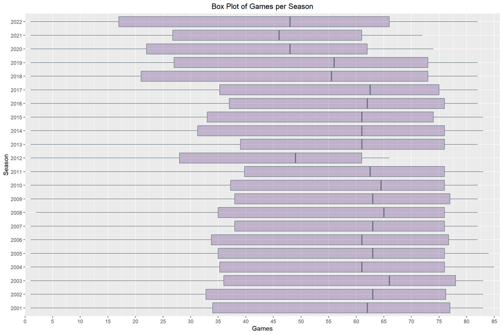

```r
ggplot(final_df_with_qs_g, aes(x=G, y=as.factor(Year))) +
  geom_boxplot(color="#63727A", fill="#5A2D81", alpha=0.3) +
  labs(title="Box Plot of Games per Season",x="Games", y = "Season")+
  theme(plot.title=element_text(hjust=0.5),
        plot.subtitle=element_text(hjust=0.5)) +
  scale_x_continuous(limits = c(0,86), expand = c(0,0), breaks=seq(0, 85, 5))
```

The season was shorten in 2012 due to a lock-out. 2020, 2021, and 2022 were shortened due to the pandemic, so their median values are a lot different than the other seasons

Remove players that fall below the 1st quartile. This reduces the player pool from 10,500 to 7,900

```r
final_df_qs_g_removed <- filter(final_df_with_qs_g, G >= quant25)
```

We’ll check for NAs again.

```r
sapply(final_df_qs_g_removed, function(x) sum(is.na(x)))
```

These stats still have missing values:

```r
setDT(final_df_qs_g_removed)
names(final_df_qs_g_removed)[final_df_qs_g_removed[,sapply(.SD, function(x) any(is.na(x))),]]
```

```
##  [1] "ThrP_PCT_pp"           "TwoP_PCT_pp"           "FT_PCT_pp"
##  [4] "FG_PCT_Dis_0_3_sho"    "FG_PCT_Dis_3_10_sho"   "FG_PCT_Dis_10_16_sho"
##  [7] "FG_PCT_Dis_16_3P_sho"  "PCT_FG_Astd_2P_sho"    "PCT_FG_Astd_3P_sho"
## [10] "Corner_3s_PCT_3PA_sho" "Corner_3s_PCT_3P_sho"
```

We’ll create a new dataframe to review a bit further

```r
final_df4 <- final_df_qs_g_removed
```

It appears that players averaging a small amount of minutes per game are still being included. These players played in a total number of games above the 1st quartile value, but didn’t really contribute much. We’ll run the same quartile method on minutes per game, using the initial final dataframe (finaldf_2) instead of the new dataframe (final_df4). The reduction will be applied to the new dataframe.

```r
q <- c(0.25,0.5,0.75)
qs_mpg_per_year <- final_df2 %>%
  group_by(Year) %>%
  summarize(quant25 = quantile(MP_pg, probs = q[1]),
            quant50 = quantile(MP_pg, probs = q[2]),
            quant75 = quantile(MP_pg, probs = q[3])) %>%
  print(n=40)
```

```
## # A tibble: 22 × 4
##     Year quant25 quant50 quant75
##    <dbl>   <dbl>   <dbl>   <dbl>
##  1  2001    11.8    19.7    28.8
##  2  2002    11.6    20.2    29.4
##  3  2003    12.3    19.7    29.3
##  4  2004    12.1    19.6    29.8
##  5  2005    12.6    19.2    29.4
##  6  2006    11.0    19.4    28.8
##  7  2007    11.2    20.2    29.5
##  8  2008    11.5    20      29.2
##  9  2009    12.1    19.8    31
## 10  2010    12.6    21.2    30
## 11  2011    12.3    20.2    28.4
## 12  2012    13.5    21      27.5
## 13  2013    12.4    19.5    28
## 14  2014    11.6    19.4    28.5
## 15  2015    13.1    19.8    27.8
## 16  2016    13      20.0    28.0
## 17  2017    12.8    19.1    27
## 18  2018    12.3    19      26.8
## 19  2019    12.3    19.2    27.2
## 20  2020    12      18.9    27.8
## 21  2021    12.6    19.6    27.7
## 22  2022    11.1    18.1    27.3
```

```r
data.frame(qs_mpg_per_year)
```

```
##    Year quant25 quant50 quant75
## 1  2001  11.800   19.70  28.800
## 2  2002  11.625   20.25  29.425
## 3  2003  12.300   19.70  29.325
## 4  2004  12.150   19.60  29.775
## 5  2005  12.600   19.25  29.425
## 6  2006  10.950   19.40  28.775
## 7  2007  11.200   20.20  29.500
## 8  2008  11.500   20.00  29.250
## 9  2009  12.100   19.80  31.000
## 10 2010  12.600   21.20  30.000
## 11 2011  12.300   20.15  28.400
## 12 2012  13.525   21.00  27.500
## 13 2013  12.400   19.50  28.000
## 14 2014  11.600   19.40  28.475
## 15 2015  13.075   19.75  27.800
## 16 2016  13.000   19.95  28.025
## 17 2017  12.800   19.10  27.000
## 18 2018  12.300   19.00  26.750
## 19 2019  12.300   19.20  27.200
## 20 2020  12.000   18.90  27.800
## 21 2021  12.575   19.60  27.700
## 22 2022  11.100   18.10  27.300
```

```r
#join final_df4 and qs
final_df_qs_mpg <- left_join(final_df4, qs_mpg_per_year[1:2], by ="Year")
```

### Plot of Minutes Per Game (MPG) per Season

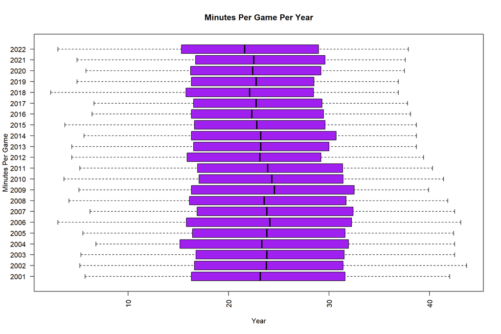

```r
boxplot(final_df_qs_mpg$MP_pg ~ final_df_qs_mpg$Year,
        main="Minutes Per Game Per Year", xlab="Year",ylab ="Minutes Per Game", horizontal=TRUE,col = "purple",las=2)
```

Remove players that fall below the 1st quartile. This reduces the player pool from 7,900 to 7,000

```r
final_df_qs_mpg_removed <- filter(final_df_qs_mpg, MP_pg >= quant25.y)
```

These stats still have missing values:

```r
setDT(final_df_qs_mpg_removed)
names(final_df_qs_mpg_removed)[final_df_qs_mpg_removed[,sapply(.SD, function(x) any(is.na(x))),]]
```

```
## [1] "ThrP_PCT_pp"           "FG_PCT_Dis_0_3_sho"    "FG_PCT_Dis_10_16_sho"
## [4] "FG_PCT_Dis_16_3P_sho"  "PCT_FG_Astd_3P_sho"    "Corner_3s_PCT_3PA_sho"
## [7] "Corner_3s_PCT_3P_sho"
```

After review, none of these players took shots from within the above distances or in the specified type of shot. For example, Andre Drummond shot zero three pointers during one of the years, so his ThrP_PCT_pp, PCT_FG_Astd_3P_sho, Corner_3s_PCT_3PA_sho, amd Corner_3s_PCT_3P_sho stat values were NA. The NA values were replaced with 0 for all instances.

```r
final_df5 <- final_df_qs_mpg_removed %>% replace(is.na(.), 0)
```

Some of the player names include an asterisk. This asterisk will be removed and a new feature will be engineered called HOF (Hall of Fame), which is a binary column indicating that

```r
final_df5$HOF <- ifelse(grepl("\\*", final_df5$Player),1,0)

final_df5 <- final_df5 %>%
  mutate(Player =gsub("\\*", "", Player))
```

Some of the player names included foreign letters. The code below removes those letters. Additionally, periods, dashes, and single quotes were removed.

```r
final_df5$Player <- stri_trans_general(final_df5$Player, "Latin-ASCII")

final_df5 <- final_df5 %>%
  mutate(Player =gsub("\\.", "", Player)) %>%
  mutate(Player =gsub("\\-", "", Player)) %>%
  mutate(Player =gsub("\\'", "", Player))
```

A unique player index was created in excel, imported, and joined to the df. The previous column that was used to remove players with more than one line per season (Tm == ‘Tot’) wasn’t useful for identifying unique players overall.

Only valuable columns for our model were selected, columns were reordered, and a few columns were renamed.

```r
PlayerIndex <- read_excel("PlayerIndex.xlsx")

final_df5 <- left_join(final_df5 ,PlayerIndex,by="Player")

final_df5 <- final_df5 %>%
  select(c(1:31,33:88,91,103)) %>% #removes player index values and player_year column and quant25
  select('Year','Player','uniqueid', everything()) %>%
  dplyr::rename(c(Pos = Pos.x, Age = Age.x))
```

The values in the Pos (position) column sometimes included multiple positions (SG-SF, PF-C, etc.). These values were ammended to only include the first position in the string.

```r
final_df5$Pos <- substr(final_df5$Pos, 1, 2)
final_df5$Pos <- str_remove_all(final_df5$Pos, "-")
final_df5 %>% distinct(Pos)
```

```
##    Pos
## 1:  PF
## 2:  SG
## 3:   C
## 4:  PG
## 5:  SF
```

Final dataframe:

```r
write.csv(final_df5, "NBACleanData.csv")
```

# Modeling

## Preparing the data

```r
#random theme I found from another site: https://alexcstern.github.io/hoopDown.html
theme_stern <- function() {
  theme(text = element_text(family='Tahoma', color="#232D4B"), # set font and color of all text
        axis.title = element_text(face='bold'), # make all axis titles bold
        plot.title = element_text(face='bold', hjust=0.5), # make all plot titles bold
        legend.title = element_text(face='bold'), # make all legend titles bold
        plot.subtitle = element_text(face='italic', hjust=0.5)) # make all subtitles italic
}
```

Read in the file

```r
mydataNba <- read_csv("NBACleanData.csv")
```

```
## ──────────────────────────────────────────────────────── Delimiter: "," chr
## (4): Player, uniqueid, Pos, Tm dbl (86): ...1, Year, Age, G, GS_pp, MP_pp,
## FG_pp, FGA_pp, FG_PCT_pp, ThrP_p...
```

Change some of the columns names for better visibility in graphs and for grouping purposes

```r
mydataNba <- mydataNba %>%
  rename(c("GS"="GS_pp","MP"="MP_pp","FGM_pp"="FG_pp","FGA_pp"="FGA_pp","FGM%"="FG_PCT_pp","ThrPM_pp"="ThrP_pp","ThrPA_pp"="ThrPA_pp","ThrPM%"="ThrP_PCT_pp","TwoPM_pp"="TwoP_pp","TwoPA_pp"="TwoPA_pp","TwoPM%"="TwoP_PCT_pp","FTM_pp"="FT_pp","FTA_pp"="FTA_pp","FTM%"="FT_PCT_pp","RebOff_pp"="ORB_pp","RebDef_pp"="DRB_pp","RebTot_pp"="TRB_pp","AST_pp"="AST_pp","STL_pp"="STL_pp","BLK_pp"="BLK_pp","TOV_pp"="TOV_pp","PF_pp"="PF_pp","PTS_pp"="PTS_pp","a_RtgOff_pp"="ORtg_pp","a_RtgDef_pp"="DRtg_pp","a_PER"="PER_adv","FGM%_true"="TS_PCT_adv","ThrP_AR"="ThrPAr_adv","FT_AR"="FTr_adv","RebOff%"="ORB_PCT_adv","RebDef%"="DRB_PCT_adv","RebTot%"="TRB_PCT_adv","AST%"="AST_PCT_adv","BLK%"="BLK_PCT_adv","TOV%"="TOV_PCT_adv","a_USG%"="USG_PCT_adv","a_WSOff"="OWS_adv","a_WSDef"="DWS_adv","a_WSTot"="WS_adv","a_WS_48"="WS_per_48_adv","a_BPMOff"="OBPM_adv","a_BPMDef"="DBPM_adv","a_BPMTot"="BPM_adv","a_VORP"="VORP_adv","FGAavgDist"="Avg_Dist_FGA_sho","FGA%_d2P"="PCT_FGA_Dis_2P_sho","FGA%_d03"="PCT_FGA_Dis_0_3_sho","FGA%_d0310"="PCT_FGA_Dis_3_10_sho","FGA%_d1016"="PCT_FGA_Dis_10_16_sho","FGA%_d163P"="PCT_FGA_Dis_16_3P_sho","FGM%_d03"="FG_PCT_Dis_0_3_sho","FGM%_d0310"="FG_PCT_Dis_3_10_sho","FGM%_d1016"="FG_PCT_Dis_10_16_sho","FGM%_d163P"="FG_PCT_Dis_16_3P_sho","Astd%2P"="PCT_FG_Astd_2P_sho","Astd%3P"="PCT_FG_Astd_3P_sho","FGA%Dunks"="Dunks_PCT_FGA_sho","DunksMade"="Dunks_sho","Thr%PAcorn"="Corner_3s_PCT_3PA_sho","Thr%PMcorn"="Corner_3s_PCT_3P_sho","HeaveA"="Heave_Att_sho","HeaveC"="Heaves_Comp_sho","MP_pg"="MP_pg","FGM_pg"="FG_pg","FGA_pg"="FGA_pg","ThrPM_pg"="ThrP_pg","ThrPA_pg"="ThrPA_pg","TwoPM_pg"="TwoP_pg","TwoPA_pg"="TwoPA_pg","FGM%e_pg"="eFG_PCT_pg","FTM_pg"="FT_pg","FTA_pg"="FTA_pg","RebOff_pg"="ORB_pg","RebDef_pg"="DRB_pg","RebTot_pg"="TRB_pg","AST_pg"="AST_pg","STL_pg"="STL_pg","BLK_pg"="BLK_pg","TOV_pg"="TOV_pg","PF_pg"="PF_pg","PTS_pg"="PTS_pg","HOF"="HOF"))
```

Remove unwanted columns. Heaves, HOF, Dunks, and Fouls are not stats we want in our model

```r
model_data <- mydataNba %>%
  select(-c(1:10,"HeaveA","HeaveC",'HOF','DunksMade','FGA%Dunks','PF_pg','PF_pp')) #remove unwanted variables
colnames(model_data)
```

```
##  [1] "FGM_pp"      "FGA_pp"      "FGM%"        "ThrPM_pp"    "ThrPA_pp"
##  [6] "ThrPM%"      "TwoPM_pp"    "TwoPA_pp"    "TwoPM%"      "FTM_pp"
## [11] "FTA_pp"      "FTM%"        "RebOff_pp"   "RebDef_pp"   "RebTot_pp"
## [16] "AST_pp"      "STL_pp"      "BLK_pp"      "TOV_pp"      "PTS_pp"
## [21] "a_RtgOff_pp" "a_RtgDef_pp" "a_PER"       "FGM%_true"   "ThrP_AR"
## [26] "FT_AR"       "RebOff%"     "RebDef%"     "RebTot%"     "AST%"
## [31] "BLK%"        "TOV%"        "a_USG%"      "a_WSOff"     "a_WSDef"
## [36] "a_WSTot"     "a_WS_48"     "a_BPMOff"    "a_BPMDef"    "a_BPMTot"
## [41] "a_VORP"      "FGAavgDist"  "FGA%_d2P"    "FGA%_d03"    "FGA%_d0310"
## [46] "FGA%_d1016"  "FGA%_d163P"  "FGM%_d03"    "FGM%_d0310"  "FGM%_d1016"
## [51] "FGM%_d163P"  "Astd%2P"     "Astd%3P"     "Thr%PAcorn"  "Thr%PMcorn"
## [56] "MP_pg"       "FGM_pg"      "FGA_pg"      "ThrPM_pg"    "ThrPA_pg"
## [61] "TwoPM_pg"    "TwoPA_pg"    "FGM%e_pg"    "FTM_pg"      "FTA_pg"
## [66] "RebOff_pg"   "RebDef_pg"   "RebTot_pg"   "AST_pg"      "STL_pg"
## [71] "BLK_pg"      "TOV_pg"      "PTS_pg"
```

Scale the data

```r
normalize <- function(x)
{
  return((x- min(x)) /(max(x)-min(x)))
}
model_data_norm <- as.data.frame(lapply(model_data, FUN=normalize))
```

Add unique row names based on Player and Year

```r
row.names(model_data_norm) <- paste(mydataNba$Player,mydataNba$Year)
```

## PCA

We’ll first look at the data using PCA to see if there’s anything we can gather

```r
model_data_norm.cor <- cor(model_data_norm)

options(scipen = 100) #removes scientific notation
Z<-eigen(model_data_norm.cor)
Z$val
```

```
##  [1] 21.52360572337259 17.41125456447871  7.05461927539057  4.13039441263942
##  [5]  3.20181748381252  2.66387146112513  2.05172422575249  1.63952113003374
##  [9]  1.51186014485574  1.35025831157161  1.19505822864048  0.95625527946016
## [13]  0.85758589839706  0.82963978164730  0.74221545947542  0.71129262890193
## [17]  0.63537714281215  0.53183055853319  0.52734507015371  0.44049133980250
## [21]  0.41071793503897  0.33135008060127  0.32359558774023  0.27408949154524
## [25]  0.26685334549794  0.23841021531251  0.18507879820439  0.15673653308141
## [29]  0.13621682893553  0.13017312621287  0.08486325098775  0.07273368683253
## [33]  0.06899586853519  0.05556953496912  0.04762412804641  0.03302895024893
## [37]  0.03180627107879  0.02783814950463  0.02417508960633  0.02307154320813
## [41]  0.01727453354443  0.01419736729391  0.01100239292136  0.01042256670136
## [45]  0.00895974555979  0.00834657107286  0.00716241749847  0.00579880345344
## [49]  0.00516546478261  0.00423215339149  0.00343983535229  0.00287295523312
## [53]  0.00263716670606  0.00207413843825  0.00194459064710  0.00118802364978
## [57]  0.00114153899115  0.00076189071330  0.00060374312471  0.00030745179000
## [61]  0.00025535712395  0.00022896976336  0.00017858958374  0.00016540080015
## [65]  0.00015267064469  0.00014556334333  0.00010140071555  0.00009251419932
## [69]  0.00008636020389  0.00006048642713  0.00004030434821  0.00001247342691
## [73]  0.00000002250971
```

There are 11 scores above 1, so we’ll run PCA on those 11 PCs

```r
pc1 <- principal(model_data_norm,nfactors=11,rotate="none",scores=TRUE)
```

Review the loadings with higher values

```r
print(pc1$loadings, digits = 3, cutoff = 0.5, sort = TRUE)
```

```
##
## Loadings:
##             PC1    PC2    PC3    PC4    PC5    PC6    PC7    PC8    PC9
## FGM_pp       0.738
## FGM.         0.594
## TwoPM_pp     0.830
## TwoPA_pp     0.739        -0.516
## FTM_pp       0.731
## FTA_pp       0.772
## PTS_pp       0.701  0.558
## a_PER        0.917
## a_USG.       0.614  0.580
## a_WSOff      0.718
## a_WSDef      0.658
## a_WSTot      0.790
## a_WS_48      0.727
## a_BPMOff     0.705  0.531
## a_BPMTot     0.717
## a_VORP       0.738
## MP_pg        0.633
## FGM_pg       0.787  0.531
## FGA_pg       0.673  0.648
## TwoPM_pg     0.888
## TwoPA_pg     0.830
## FTM_pg       0.785
## FTA_pg       0.831
## RebOff_pg    0.668 -0.573
## RebDef_pg    0.787
## RebTot_pg    0.797
## BLK_pg       0.571
## TOV_pg       0.655
## PTS_pg       0.757  0.600
## FGA_pp       0.506  0.636
## ThrPM_pp            0.738
## ThrPA_pp            0.744
## ThrPM.              0.676
## FTM.                0.637
## RebOff_pp          -0.807
## RebDef_pp    0.552 -0.596
## RebTot_pp    0.541 -0.727
```

[output cut: 104 more lines]

```
## FGA._d1016
## FGM._d03
## FGM._d0310
## FGM._d1016
## FGM._d163P
## Astd.3P
##
##                   PC1    PC2   PC3   PC4   PC5   PC6   PC7   PC8   PC9  PC10
## SS loadings    21.524 17.411 7.055 4.130 3.202 2.664 2.052 1.640 1.512 1.350
## Proportion Var  0.295  0.239 0.097 0.057 0.044 0.036 0.028 0.022 0.021 0.018
## Cumulative Var  0.295  0.533 0.630 0.687 0.730 0.767 0.795 0.817 0.838 0.857
##                 PC11
## SS loadings    1.195
## Proportion Var 0.016
## Cumulative Var 0.873
```

Plot the percentage of explained variance for each PC

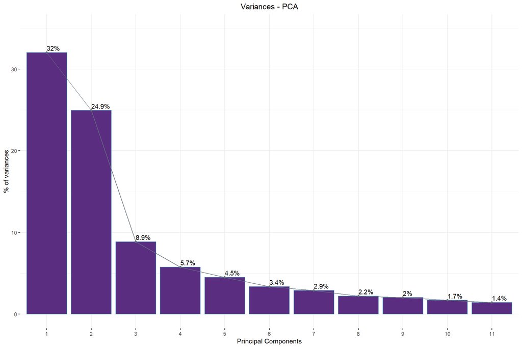

```r
pca <- prcomp(model_data_norm)
fviz_eig(pca, addlabels = TRUE, ylim = c(0, 35), ncp = 11,
         barfill = "#5A2D81",
         linecolor = "#63727A") +
  labs(title = "Variances - PCA",x = "Principal Components", y = "% of variances") +
  theme(plot.title=element_text(hjust=0.5),
        plot.subtitle=element_text(hjust=0.5))
```

PCA helped us analyze the data in a lower dimensional space, but we want to try a different clustering method

## K-Means

For k-means to run, we need to determine the number of clusters for the algorithm.

```r
set.seed(123) # set seed to ensure reproduceability
MAX_K <- 20 # max number of clusters
sse <- c() # vector to hold SSE of each model

for (k in 1:MAX_K) {
  algo_k <- kmeans(model_data_norm, centers=k, nstart=25, iter.max=20,algorithm="MacQueen") # k-means algorithm
  sse <- c(sse, algo_k$tot.withinss) # get SSE
}
```

Generally, where the plot levels off or wherever there’s an elbow is a good way to find the optimal number of clusters.

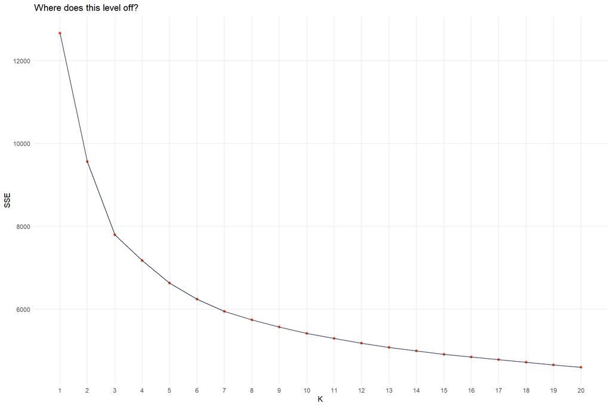

```r
tibble(k = 1:MAX_K, SSE = sse) %>%
  ggplot(aes(x=k, y=SSE)) +
  geom_point(color="#F84C1E") + geom_line(color="#232D4B") +
  labs(x = "K", y = "SSE", title = "Where does this level off?") +
  scale_x_continuous(breaks=seq(1, MAX_K, 1)) +
  theme_minimal() + #theme_stern() +
  theme(panel.grid.minor.x = element_blank(), panel.grid.minor.y = element_blank())
```

The plot below doesn’t really show either, so we plot can look at the difference between total within cluster distance for k and k+1

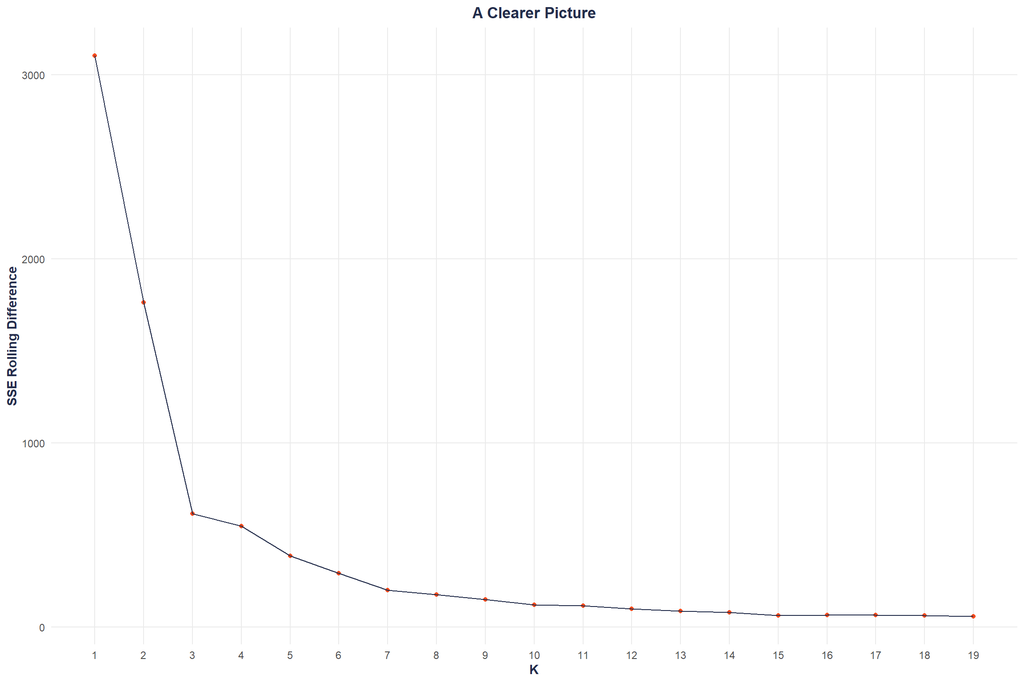

```r
tibble(k = 1:MAX_K, SSE_difference = sse-lead(sse)) %>%
  dplyr::filter(k<MAX_K) %>%
  ggplot(aes(x=k, y=SSE_difference)) +
  geom_point(color="#F84C1E") + geom_line(color="#232D4B") +
  labs(x = "K", y = "SSE Rolling Difference", title = "A Clearer Picture") +
  scale_x_continuous(breaks=seq(1, MAX_K, 1)) +
  theme_minimal() + theme_stern() +
  theme(panel.grid.minor.x = element_blank(), panel.grid.minor.y = element_blank())
```

This looks to be between 7 or 10, but if we run with a two unit rolling distance, it might give us an even better picture

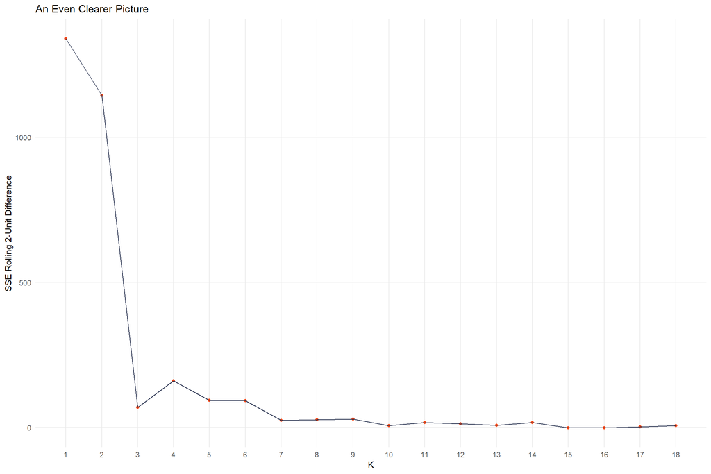

```r
tibble(k = 1:MAX_K, SSE_difference = sse-2*lead(sse)+lead(sse, 2)) %>%
  dplyr::filter(k<MAX_K-1) %>%
  ggplot(aes(x=k, y=SSE_difference)) +
  geom_point(color="#F84C1E") + geom_line(color="#232D4B") +
  labs(x = "K", y = "SSE Rolling 2-Unit Difference", title = "An Even Clearer Picture") +
  scale_x_continuous(breaks=seq(1, MAX_K, 1)) +
  theme_minimal() + #theme_stern() +
  theme(panel.grid.minor.x = element_blank(), panel.grid.minor.y = element_blank())
```

Here it’s pretty clear that 7 is about where the data levels off, so we will use that for our clustering algo

```r
colnames(model_data_norm) <- gsub(x = colnames(model_data_norm), pattern = "\\.", replacement = "%") # make sure columns are named correctly
K <- 7
kmeans8 <- kmeans(model_data_norm, centers=K, nstart=25, iter.max=20)
km_centers <- data.frame(kmeans8$centers) # SCALED cluster centers/means
model_data_clusters <- data.frame(Cluster = kmeans8$cluster, model_data_norm)

# name clusters before pivoting
km_centers$Cluster <- c('Cluster 1', 'Cluster 2', 'Cluster 3',
                        'Cluster 4', 'Cluster 5', 'Cluster 6',
                        'Cluster 7')

km_centers <- km_centers %>%
  pivot_longer(!Cluster, names_to = 'feature', values_to = 'z_val') # pivot data to make plotting easier
colnames(km_centers) <- gsub(x = colnames(km_centers), pattern = "\\.", replacement = "%")

# reset the order of predictor variables for plotting
km_centers$feature <- factor(km_centers$feature)

# reset the order of clusters for plotting (cluster 10 would default to come after cluster 1 and before cluster 2)
km_centers$Cluster <- factor(km_centers$Cluster, levels=c('Cluster 1', 'Cluster 2', 'Cluster 3',
                                                          'Cluster 4', 'Cluster 5', 'Cluster 6',
                                                          'Cluster 7'))
```

After clustering was done, we were left with seven new player types: 1. Well-Rounded Bigs 2. Physical Bigs 3. Game Generals 4. Game Lieutenants 5. Shot-Creating Sharpshooters 6. MVP Bigs 7. Three-Point Threats

Below is a plot of one of the clusters. The dark dot indicates where that cluster ranks compared to the other clusters for each stat. The dotted lines act as a partition to differentiate between the categories of statistics

If we look towards the right of the graph, we’ll see that the players in this cluster rank towards the bottom of the ThrP (three point) shooting categories. They’re at the top in FGA_d2p (Field goal attempts that were two-point shots), which is inline with them ranking last in most three-point shooting categories. They’re also towards the top in a lot of the rebounding categories. A more deatiled description is included below.

#### Physical Bigs

- 19 players in 2022. Examples - Andre Drummond, Clint Capela, DeAndre Jordan
- Specific types of a traditional center. Physical, strong, hang out close to the rim. Don’t get a ton of playing time or points, but physical presence is felt on both ends of the floor

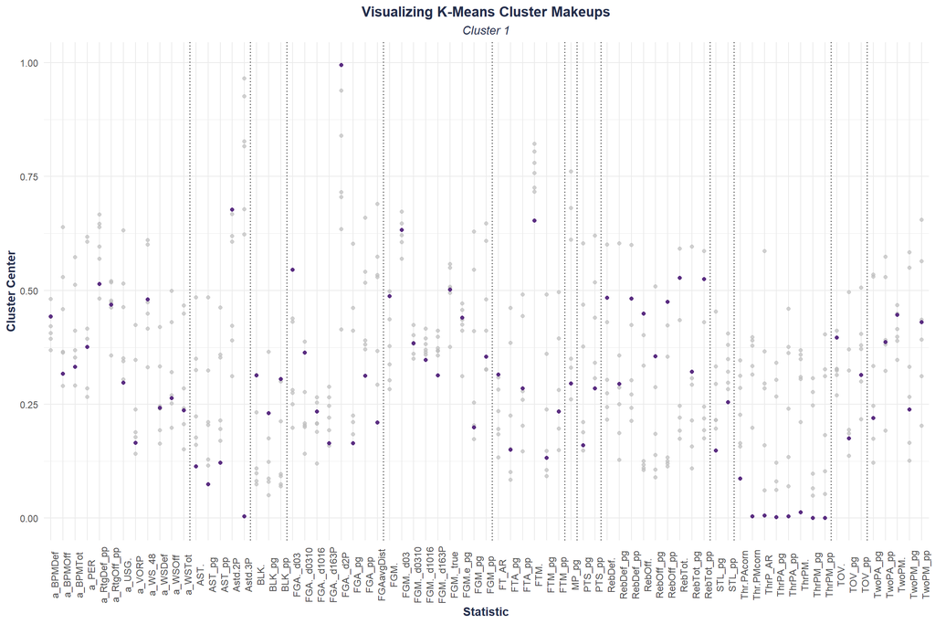

```r
km_centers %>%
  ggplot(aes(x=feature, y=z_val, color=Cluster)) +
  geom_point(color="#5A2D81") + # color points
  gghighlight(Cluster=='Cluster 1', use_direct_label = FALSE) + # highlight cluster 1
  labs(x = "Statistic", y = "Cluster Center",  # axis labels
       title = "Visualizing K-Means Cluster Makeups", # plot title
       subtitle = "Cluster 1") +  # plot subtitle
  theme_minimal() + theme_stern() + # add themes
  theme(legend.position = "none", # manually adjust themes
        axis.text.x = element_text(angle=90, size=9)) +
  geom_vline(xintercept = c(12.5, 17.5, 20.5, 28.5, 37.5, 43.5, 44.5, 46.5, 55.5, 57.5, 65.5, 68.5),linetype="dotted")
```

```r
abc <- tibble(cluster=kmeans8$cluster, mydataNba$Player, season=mydataNba$Year) %>%
  dplyr::filter(cluster==1, season==2022)
abc
```

```
## # A tibble: 19 × 3
##    cluster `mydataNba$Player` season
##      <int> <chr>               <dbl>
##  1       1 Andre Drummond       2022
##  2       1 Bismack Biyombo      2022
##  3       1 Clint Capela         2022
##  4       1 Cody Zeller          2022
##  5       1 Daniel Gafford       2022
##  6       1 DeAndre Jordan       2022
##  7       1 Hassan Whiteside     2022
##  8       1 Ivica Zubac          2022
##  9       1 Jericho Sims         2022
## 10       1 Kevon Looney         2022
## 11       1 Khem Birch           2022
## 12       1 Mason Plumlee        2022
## 13       1 Mitchell Robinson    2022
## 14       1 Nerlens Noel         2022
## 15       1 Nic Claxton          2022
## 16       1 Onyeka Okongwu       2022
## 17       1 Robert Williams      2022
## 18       1 Steven Adams         2022
## 19       1 Udoka Azubuike       2022
```

#### Game Lieutenants

- 39 Players in 2022. Examples - Lou Williams, Markieff Morris, Rajon Rondo
- Generally come in off the bench, provide a supporting role on the offensive end as ball handlers. Only rank in the top 3 for 10 stats, rank second to last in 14 stats, rank last in 30 stats.

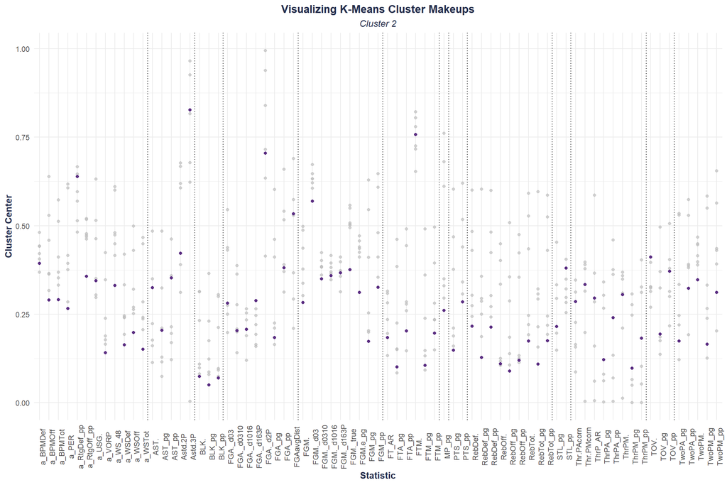

```r
km_centers %>%
  ggplot(aes(x=feature, y=z_val, color=Cluster)) +
  geom_point(color="#5A2D81") + # color points
  gghighlight(Cluster=='Cluster 2', use_direct_label = FALSE) + # highlight cluster 1
  labs(x = "Statistic", y = "Cluster Center",  # axis labels
       title = "Visualizing K-Means Cluster Makeups", # plot title
       subtitle = "Cluster 2") +  # plot subtitle
  theme_minimal() + theme_stern() + # add themes
  theme(legend.position = "none", # manually adjust themes
        axis.text.x = element_text(angle=90, size=9)) +
  geom_vline(xintercept = c(12.5, 17.5, 20.5, 28.5, 37.5, 43.5, 44.5, 46.5, 55.5, 57.5, 65.5, 68.5),linetype="dotted")
```

```r
abc <- tibble(cluster=kmeans8$cluster, mydataNba$Player, season=mydataNba$Year) %>%
  dplyr::filter(cluster==2, season==2022)
abc
```

```
## # A tibble: 39 × 3
##    cluster `mydataNba$Player` season
##      <int> <chr>               <dbl>
##  1       2 Aaron Holiday        2022
##  2       2 Brad Wanamaker       2022
##  3       2 Brandon Boston Jr    2022
##  4       2 Brandon Goodwin      2022
##  5       2 Cam Thomas           2022
##  6       2 CJ Elleby            2022
##  7       2 Cory Joseph          2022
##  8       2 David Duke Jr        2022
##  9       2 Dennis Smith Jr      2022
## 10       2 Eric Bledsoe         2022
## # … with 29 more rows
```

#### Shot-Creating Sharpshooters

- 66 players in 2022. Examples - D’Angelo Russell, Derrick Rose, Klay Thompson
- Don’t rank first in any of the stats, however they’re still important to the team. Love shooting threes, getting assists. Rank third in a lot of categories, given the dominance of the Game Generals and MVP Bigs

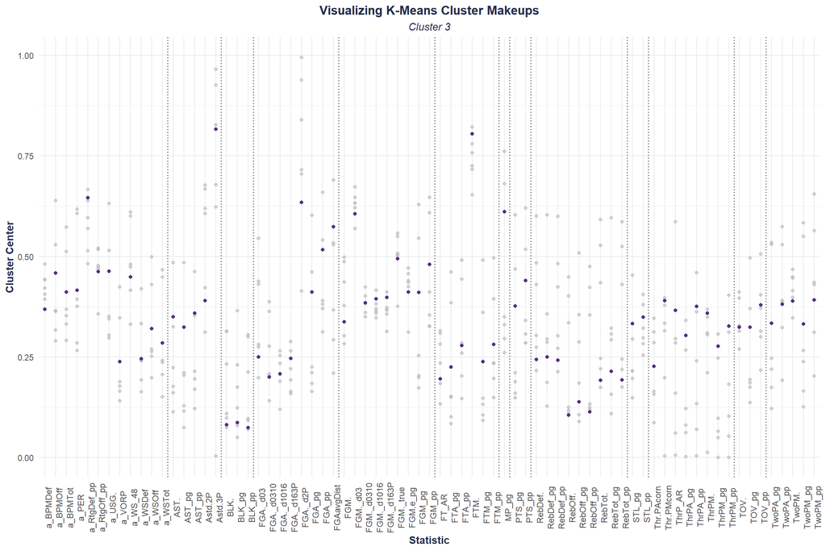

```r
km_centers %>%
  ggplot(aes(x=feature, y=z_val, color=Cluster)) +
  geom_point(color="#5A2D81") + # color points
  gghighlight(Cluster=='Cluster 3', use_direct_label = FALSE) + # highlight cluster 1
  labs(x = "Statistic", y = "Cluster Center",  # axis labels
       title = "Visualizing K-Means Cluster Makeups", # plot title
       subtitle = "Cluster 3") +  # plot subtitle
  theme_minimal() + theme_stern() + # add themes
  theme(legend.position = "none", # manually adjust themes
        axis.text.x = element_text(angle=90, size=9)) +
  geom_vline(xintercept = c(12.5, 17.5, 20.5, 28.5, 37.5, 43.5, 44.5, 46.5, 55.5, 57.5, 65.5, 68.5),linetype="dotted")
```

```r
abc <- tibble(cluster=kmeans8$cluster, mydataNba$Player, season=mydataNba$Year) %>%
  dplyr::filter(cluster==3, season==2022)
abc
```

```
## # A tibble: 66 × 3
##    cluster `mydataNba$Player` season
##      <int> <chr>               <dbl>
##  1       3 Aaron Gordon         2022
##  2       3 Andrew Wiggins       2022
##  3       3 Anfernee Simons      2022
##  4       3 Anthony Edwards      2022
##  5       3 Bogdan Bogdanovic    2022
##  6       3 Bojan Bogdanovic     2022
##  7       3 Brandon Williams     2022
##  8       3 Cade Cunningham      2022
##  9       3 Cameron Payne        2022
## 10       3 Caris LeVert         2022
## # … with 56 more rows
```

#### Well-Rounded Bigs

- 76 players in 2022. Examples - Al Horford, DeMarcus Cousins, and Dwight Howard
- Only rank first or second in a few stats, but they don’t rank last. Interestingly, they rank fourth in 30 of the 73 statistics - which is average among the seven new player types

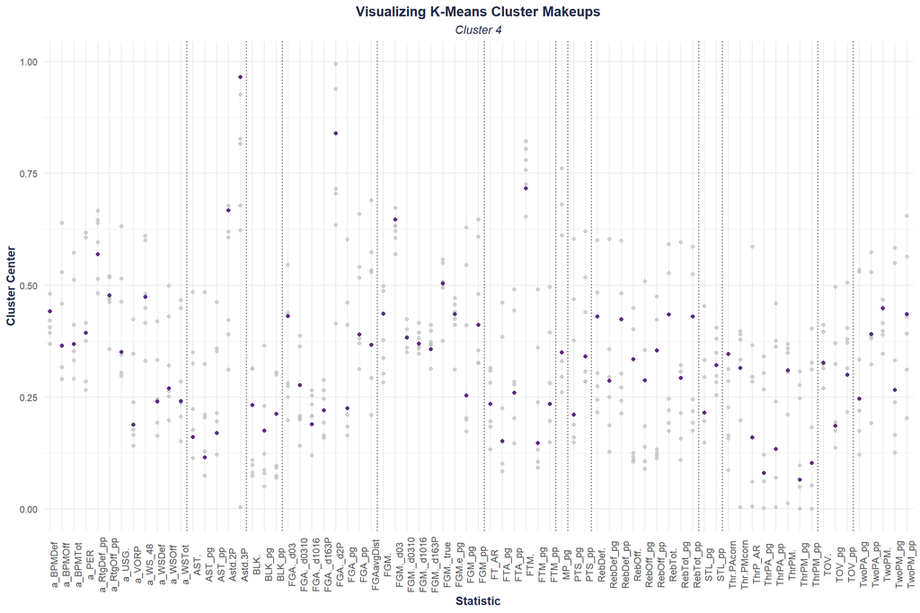

```r
km_centers %>%
  ggplot(aes(x=feature, y=z_val, color=Cluster)) +
  geom_point(color="#5A2D81") + # color points
  gghighlight(Cluster=='Cluster 4', use_direct_label = FALSE) + # highlight cluster 1
  labs(x = "Statistic", y = "Cluster Center",  # axis labels
       title = "Visualizing K-Means Cluster Makeups", # plot title
       subtitle = "Cluster 4") +  # plot subtitle
  theme_minimal() + theme_stern() + # add themes
  theme(legend.position = "none", # manually adjust themes
        axis.text.x = element_text(angle=90, size=9)) +
  geom_vline(xintercept = c(12.5, 17.5, 20.5, 28.5, 37.5, 43.5, 44.5, 46.5, 55.5, 57.5, 65.5, 68.5),linetype="dotted")
```

```r
abc <- tibble(cluster=kmeans8$cluster, mydataNba$Player, season=mydataNba$Year) %>%
  dplyr::filter(cluster==4, season==2022)
abc
```

```
## # A tibble: 76 × 3
##    cluster `mydataNba$Player` season
##      <int> <chr>               <dbl>
##  1       4 Al Horford           2022
##  2       4 Alex Len             2022
##  3       4 Alperen Sengun       2022
##  4       4 Bobby Portis         2022
##  5       4 Brandon Clarke       2022
##  6       4 Bruce Brown          2022
##  7       4 Chimezie Metu        2022
##  8       4 Chris Boucher        2022
##  9       4 Damian Jones         2022
## 10       4 Daniel Theis         2022
## # … with 66 more rows
```

#### Game Generals

- 30 players in 2022. Examples - LeBron James, James Harden, Stephen Curry
- Rank first in 31 stats, second in 9, only rank below average in 7 stats. These players do it all, generally lead in the advanced stats. Control the speed and pace of the game, generally include the teams’ main ball handler.

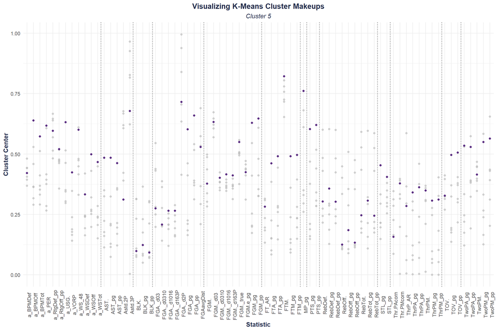

```r
km_centers %>%
  ggplot(aes(x=feature, y=z_val, color=Cluster)) +
  geom_point(color="#5A2D81") + # color points
  gghighlight(Cluster=='Cluster 5', use_direct_label = FALSE) + # highlight cluster 1
  labs(x = "Statistic", y = "Cluster Center",  # axis labels
       title = "Visualizing K-Means Cluster Makeups", # plot title
       subtitle = "Cluster 5") +  # plot subtitle
  theme_minimal() + theme_stern() + # add themes
  theme(legend.position = "none", # manually adjust themes
        axis.text.x = element_text(angle=90, size=9)) +
  geom_vline(xintercept = c(12.5, 17.5, 20.5, 28.5, 37.5, 43.5, 44.5, 46.5, 55.5, 57.5, 65.5, 68.5),linetype="dotted")
```

```r
abc <- tibble(cluster=kmeans8$cluster, mydataNba$Player, season=mydataNba$Year) %>%
  dplyr::filter(cluster==5, season==2022)
abc
```

```
## # A tibble: 30 × 3
##    cluster `mydataNba$Player` season
##      <int> <chr>               <dbl>
##  1       5 Bradley Beal         2022
##  2       5 Brandon Ingram       2022
##  3       5 Chris Paul           2022
##  4       5 Damian Lillard       2022
##  5       5 Darius Garland       2022
##  6       5 DeAaron Fox          2022
##  7       5 Dejounte Murray      2022
##  8       5 DeMar DeRozan        2022
##  9       5 Devin Booker         2022
## 10       5 Donovan Mitchell     2022
## # … with 20 more rows
```

#### MVP Bigs

- 20 players in 2022. Examples - Giannis Antetokounmpo, Joel Embiid, Nikola Jokic
- The players mentioned above were top 3 in the 2022 NBA MVP race. That alone emphasizes the importance of this position. Rank first in 22 stats, second in 29 (mostly second only to Floor Generals)

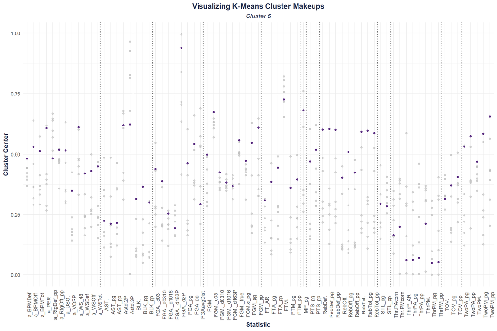

```r
km_centers %>%
  ggplot(aes(x=feature, y=z_val, color=Cluster)) +
  geom_point(color="#5A2D81") + # color points
  gghighlight(Cluster=='Cluster 6', use_direct_label = FALSE) + # highlight cluster 1
  labs(x = "Statistic", y = "Cluster Center",  # axis labels
       title = "Visualizing K-Means Cluster Makeups", # plot title
       subtitle = "Cluster 6") +  # plot subtitle
  theme_minimal() + theme_stern() + # add themes
  theme(legend.position = "none", # manually adjust themes
        axis.text.x = element_text(angle=90, size=9)) +
  geom_vline(xintercept = c(12.5, 17.5, 20.5, 28.5, 37.5, 43.5, 44.5, 46.5, 55.5, 57.5, 65.5, 68.5),linetype="dotted")
```

```r
abc <- tibble(cluster=kmeans8$cluster, mydataNba$Player, season=mydataNba$Year) %>%
  dplyr::filter(cluster==6, season==2022)
abc
```

```
## # A tibble: 20 × 3
##    cluster `mydataNba$Player`    season
##      <int> <chr>                  <dbl>
##  1       6 Anthony Davis           2022
##  2       6 Bam Adebayo             2022
##  3       6 Christian Wood          2022
##  4       6 Deandre Ayton           2022
##  5       6 Domantas Sabonis        2022
##  6       6 Evan Mobley             2022
##  7       6 Giannis Antetokounmpo   2022
##  8       6 Jakob Poeltl            2022
##  9       6 Jarrett Allen           2022
## 10       6 JaVale McGee            2022
## 11       6 Joel Embiid             2022
## 12       6 Jonas Valanciunas       2022
## 13       6 Jusuf Nurkic            2022
## 14       6 KarlAnthony Towns       2022
## 15       6 Kristaps Porzingis      2022
## 16       6 Montrezl Harrell        2022
## 17       6 Nikola Jokic            2022
## 18       6 Nikola Vucevic          2022
## 19       6 Rudy Gobert             2022
## 20       6 Wendell Carter Jr       2022
```

#### Three-Point Threats

- 156 players in 2022. Examples - Blake Griffin, Carmelo Anthony, Lonzo Ball
- By far the most common, which makes sense given how the NBA has evolved towards the 3-point shot. Generally rank first or second in 3-point shooting categories (resembling Shot-Creating Sharpshooters) .

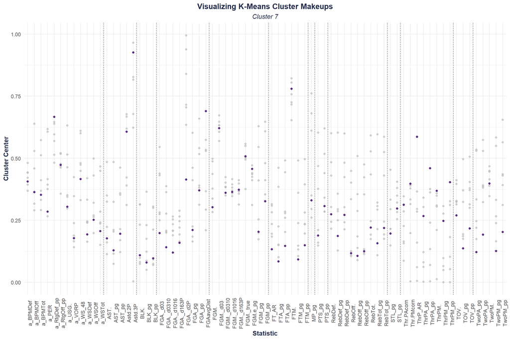

```r
km_centers %>%
  ggplot(aes(x=feature, y=z_val, color=Cluster)) +
  geom_point(color="#5A2D81") + # color points
  gghighlight(Cluster=='Cluster 7', use_direct_label = FALSE) + # highlight cluster 1
  labs(x = "Statistic", y = "Cluster Center",  # axis labels
       title = "Visualizing K-Means Cluster Makeups", # plot title
       subtitle = "Cluster 7") +  # plot subtitle
  theme_minimal() + theme_stern() + # add themes
  theme(legend.position = "none", # manually adjust themes
        axis.text.x = element_text(angle=90, size=9)) +
  geom_vline(xintercept = c(12.5, 17.5, 20.5, 28.5, 37.5, 43.5, 44.5, 46.5, 55.5, 57.5, 65.5, 68.5),linetype="dotted")
```

```r
abc <- tibble(cluster=kmeans8$cluster, mydataNba$Player, season=mydataNba$Year) %>%
  dplyr::filter(cluster==7, season==2022)
abc
```

```
## # A tibble: 156 × 3
##    cluster `mydataNba$Player` season
##      <int> <chr>               <dbl>
##  1       7 Aaron Wiggins        2022
##  2       7 Admiral Schofield    2022
##  3       7 Alec Burks           2022
##  4       7 Aleksej Pokusevski   2022
##  5       7 Alex Caruso          2022
##  6       7 Alfonzo McKinnie     2022
##  7       7 Amir Coffey          2022
##  8       7 Andre Iguodala       2022
##  9       7 Armoni Brooks        2022
## 10       7 Austin Reaves        2022
## # … with 146 more rows
```

## Analysis of 2022 Players

```r
model_data_clusters1 <- model_data_clusters
model_data_clusters1$Year <- mydataNba$Year
model_data_clusters1$Pos <- mydataNba$Pos
model_data_clusters1$Player <- mydataNba$Player
model_data_clusters1$Tm <- mydataNba$Tm

model_data_clusters2022 <- model_data_clusters1 %>%
  filter(Year == 2022)
```

### Historical and Current Cluster Analysis

The below plot shows how the player types have evolved since the 2000-2001 season and a brief summary of each cluster is included.

- Well-Rounded Bigs have had their ups and downs, ranging from 9.3% to 19% of players in the league, however it’s not that different today than it is from 2001.
- Physical Bigs have steadily decreased and the position appears close to becoming obsolete. As the style of play has changed, so has the need for this specific player type.
- Game Generals have more or less remained consistent. This player type has been valued every season.
- Game Lieutenants have steadily decreased, which is interesting, but it’s likely that Game Lieutenants have transitioned into Three-Point Threats over the years.
- Shot-Creating Sharpshooters have had equal periods of increase and decrease.
- MVP Bigs have remained relatively constant, but appear to be phasing out.
- Three-Point Threats have grown significantly over the date range. It’s a clear indication that 3-point shooters are more common than ever.

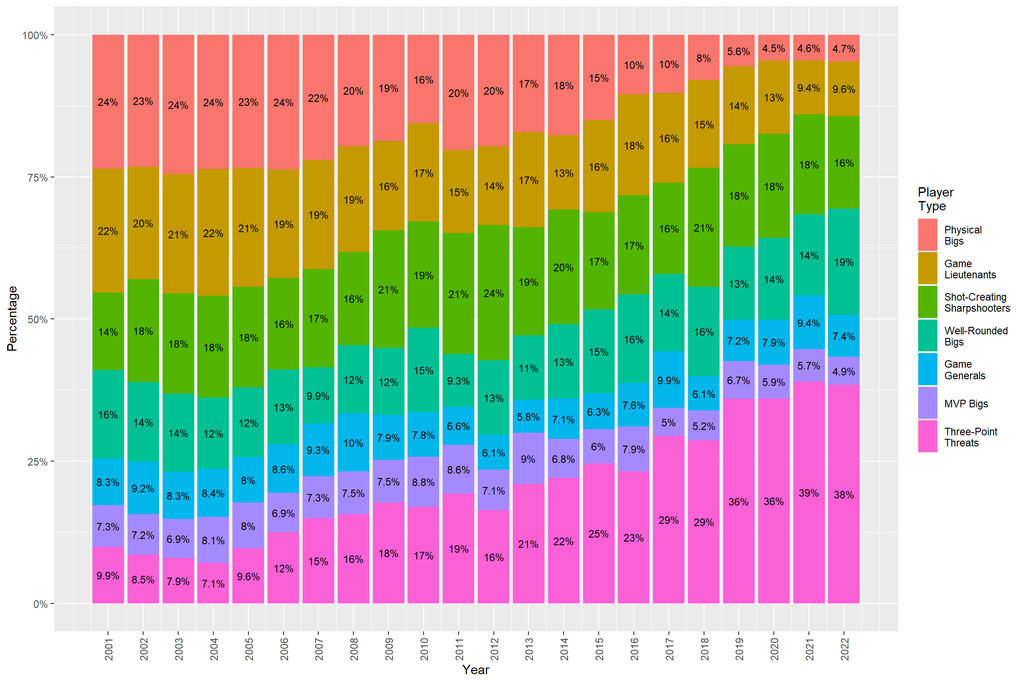

```r
ggplot(model_data_clusters1, aes(x=Year, fill=factor(Cluster))) +
  geom_bar(position="fill") +
  geom_text(
    aes(label=paste0(signif(..count.. / tapply(..count.., ..x.., sum)[as.character(..x..)]*100, digits=2),"%")),
    stat="count",
    position=position_fill(vjust=0.5),colour="black", size=3) +
  labs(y="Percentage") +
  scale_x_continuous("Year", breaks=seq(2001,2022,by=1)) +
  scale_y_continuous(labels = scales::percent_format(accuracy = 1)) +
  theme(axis.text.x = element_text(angle = 90, vjust = 0.5, hjust=1)) +
  scale_fill_discrete(name = "Player\nType", labels =c('Physical\nBigs', 'Game\nLieutenants', 'Shot-Creating\nSharpshooters', 'Well-Rounded\nBigs', 'Game\nGenerals', 'MVP Bigs', 'Three-Point\nThreats')) +
  theme(legend.key.height=unit(1, "cm"))
```

The plot below displays the count of each traditional player position (C, PF, SF, SG, PG) within each of the new clusters (i.e. new player types).

- Of the seven new player types, Well-Rounded Bigs, Shot-Creating Sharpshooters, and Three-Point Threats include players from all 5 traditional positions.
- Game Generals and Game Lieutenants contain players from all but the traditional center position
- Physical Bigs and MVP Bigs contain the traditional center position with a sprinkling of the traditional power forward position.

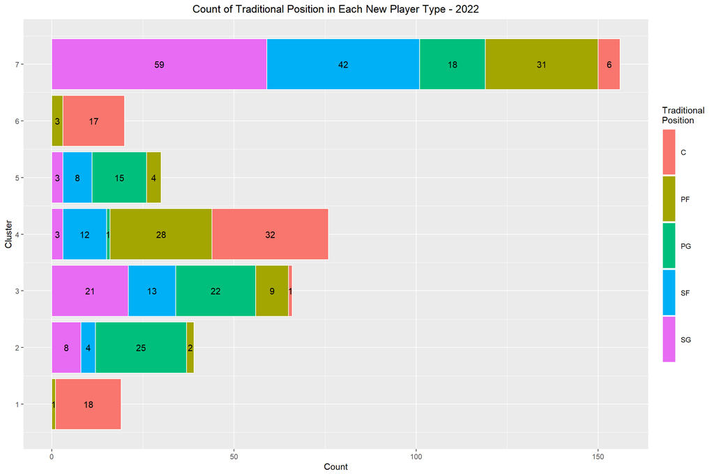

```r
ggplot(model_data_clusters2022, aes(y = Cluster, fill = Pos)) +
  geom_bar(aes(x = (..count..)),colour="white") +
  geom_text(stat='count', aes(label=..count..),position = position_stack(vjust = 0.5), color = "black") +
  ggtitle("Count of Traditional Position in Each New Player Type - 2022") +
  theme(plot.title = element_text(hjust = 0.5)) +
  scale_y_continuous(name="Cluster", breaks = c(1,2,3,4,5,6,7)) +
  labs(fill = "Traditional\nPosition", x = "Count") +
  theme(legend.key.height=unit(2, "cm"))
```

Plot the makeup of each team in 2022

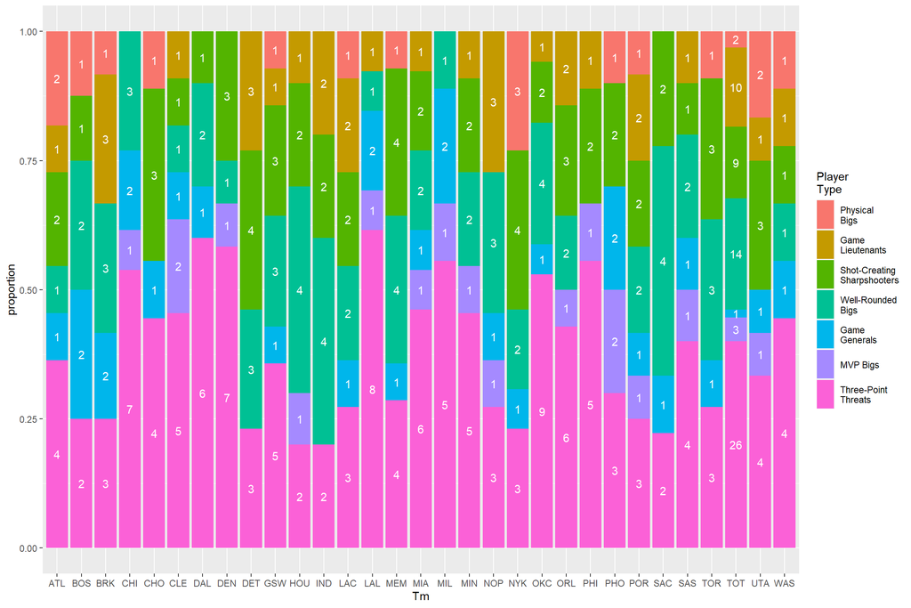

```r
#teams by cluster
ggplot(data = model_data_clusters2022, aes(x = Tm, fill = factor(Cluster))) +
  geom_bar(position = "fill") + ylab("proportion") +
  stat_count(geom = "text",
             aes(label = stat(count)),
             position=position_fill(vjust=0.5), colour="white") +
    scale_fill_discrete(name = "Player\nType", labels =c('Physical\nBigs', 'Game\nLieutenants', 'Shot-Creating\nSharpshooters', 'Well-Rounded\nBigs', 'Game\nGenerals', 'MVP Bigs', 'Three-Point\nThreats')) +
  theme(legend.key.height=unit(1, "cm"))
```

TOT is populating as a team, which is a combination of data from when a player was traded, need to fix

```r
###Big gsub code#####
model_data_clusters2022 <- model_data_clusters2022 %>%
  mutate(Tm =ifelse(Player =='Aaron Holiday', gsub('TOT','PHO',Tm),Tm)) %>%
  mutate(Tm =ifelse(Player =='Andre Drummond', gsub('TOT','BRK',Tm),Tm)) %>%
  mutate(Tm =ifelse(Player =='Armoni Brooks', gsub('TOT','TOR',Tm),Tm)) %>%
  mutate(Tm =ifelse(Player =='Brad Wanamaker', gsub('TOT','WAS',Tm),Tm)) %>%
  mutate(Tm =ifelse(Player =='Bryn Forbes', gsub('TOT','DEN',Tm),Tm)) %>%
  mutate(Tm =ifelse(Player =='Buddy Hield', gsub('TOT','IND',Tm),Tm)) %>%
  mutate(Tm =ifelse(Player =='Cam Reddish', gsub('TOT','NYK',Tm),Tm)) %>%
  mutate(Tm =ifelse(Player =='Caris LeVert', gsub('TOT','CLE',Tm),Tm)) %>%
  mutate(Tm =ifelse(Player =='CJ McCollum', gsub('TOT','NOP',Tm),Tm)) %>%
  mutate(Tm =ifelse(Player =='DJ Augustin', gsub('TOT','LAL',Tm),Tm)) %>%
  mutate(Tm =ifelse(Player =='Daniel Theis', gsub('TOT','BOS',Tm),Tm)) %>%
  mutate(Tm =ifelse(Player =='Danuel House Jr', gsub('TOT','UTA',Tm),Tm)) %>%
  mutate(Tm =ifelse(Player =='Davis Bertans', gsub('TOT','DAL',Tm),Tm)) %>%
  mutate(Tm =ifelse(Player =='DeAndre Bembry', gsub('TOT','MIL',Tm),Tm)) %>%
  mutate(Tm =ifelse(Player =='DeAndre Jordan', gsub('TOT','PHI',Tm),Tm)) %>%
  mutate(Tm =ifelse(Player =='DeMarcus Cousins', gsub('TOT','DEN',Tm),Tm)) %>%
  mutate(Tm =ifelse(Player =='Dennis Schroder', gsub('TOT','HOU',Tm),Tm)) %>%
  mutate(Tm =ifelse(Player =='Derrick White', gsub('TOT','BOS',Tm),Tm)) %>%
  mutate(Tm =ifelse(Player =='Domantas Sabonis', gsub('TOT','SAC',Tm),Tm)) %>%
  mutate(Tm =ifelse(Player =='Donte DiVincenzo', gsub('TOT','SAC',Tm),Tm)) %>%
  mutate(Tm =ifelse(Player =='Drew Eubanks', gsub('TOT','POR',Tm),Tm)) %>%
  mutate(Tm =ifelse(Player =='Elijah Hughes', gsub('TOT','POR',Tm),Tm)) %>%
  mutate(Tm =ifelse(Player =='Goran Dragic', gsub('TOT','BRK',Tm),Tm)) %>%
  mutate(Tm =ifelse(Player =='Isaiah Thomas', gsub('TOT','CHO',Tm),Tm)) %>%
  mutate(Tm =ifelse(Player =='Ish Smith', gsub('TOT','WAS',Tm),Tm)) %>%
  mutate(Tm =ifelse(Player =='Jalen Smith', gsub('TOT','IND',Tm),Tm)) %>%
  mutate(Tm =ifelse(Player =='James Harden', gsub('TOT','PHI',Tm),Tm)) %>%
  mutate(Tm =ifelse(Player =='Javonte Smart', gsub('TOT','MIA',Tm),Tm)) %>%
  mutate(Tm =ifelse(Player =='Jeremy Lamb', gsub('TOT','SAC',Tm),Tm)) %>%
  mutate(Tm =ifelse(Player =='Jevon Carter', gsub('TOT','MIL',Tm),Tm)) %>%
  mutate(Tm =ifelse(Player =='Josh Hart', gsub('TOT','POR',Tm),Tm)) %>%
  mutate(Tm =ifelse(Player =='Josh Jackson', gsub('TOT','SAC',Tm),Tm)) %>%
  mutate(Tm =ifelse(Player =='Josh Richardson', gsub('TOT','SAS',Tm),Tm)) %>%
  mutate(Tm =ifelse(Player =='Juancho Hernangomez', gsub('TOT','UTA',Tm),Tm)) %>%
  mutate(Tm =ifelse(Player =='Justin Holiday', gsub('TOT','SAC',Tm),Tm)) %>%
  mutate(Tm =ifelse(Player =='Justin Robinson', gsub('TOT','DET',Tm),Tm)) %>%
  mutate(Tm =ifelse(Player =='Justise Winslow', gsub('TOT','POR',Tm),Tm)) %>%
  mutate(Tm =ifelse(Player =='Kelan Martin', gsub('TOT','BOS',Tm),Tm)) %>%
  mutate(Tm =ifelse(Player =='Keon Johnson', gsub('TOT','POR',Tm),Tm)) %>%
  mutate(Tm =ifelse(Player =='Kristaps Porzingis', gsub('TOT','WAS',Tm),Tm)) %>%
  mutate(Tm =ifelse(Player =='Lance Stephenson', gsub('TOT','IND',Tm),Tm)) %>%
  mutate(Tm =ifelse(Player =='Larry Nance Jr', gsub('TOT','NOP',Tm),Tm)) %>%
  mutate(Tm =ifelse(Player =='Malcolm Hill', gsub('TOT','CHI',Tm),Tm)) %>%
  mutate(Tm =ifelse(Player =='Marvin Bagley III', gsub('TOT','DET',Tm),Tm)) %>%
  mutate(Tm =ifelse(Player =='Montrezl Harrell', gsub('TOT','CHO',Tm),Tm)) %>%
  mutate(Tm =ifelse(Player =='Mychal Mulder', gsub('TOT','MIA',Tm),Tm)) %>%
  mutate(Tm =ifelse(Player =='Nickeil AlexanderWalker', gsub('TOT','UTA',Tm),Tm)) %>%
  mutate(Tm =ifelse(Player =='Norman Powell', gsub('TOT','LAC',Tm),Tm)) %>%
  mutate(Tm =ifelse(Player =='Paul Millsap', gsub('TOT','PHI',Tm),Tm)) %>%
  mutate(Tm =ifelse(Player =='Rajon Rondo', gsub('TOT','CLE',Tm),Tm)) %>%
  mutate(Tm =ifelse(Player =='Robert Covington', gsub('TOT','LAC',Tm),Tm)) %>%
  mutate(Tm =ifelse(Player =='Rodney Hood', gsub('TOT','LAC',Tm),Tm)) %>%
  mutate(Tm =ifelse(Player =='Romeo Langford', gsub('TOT','SAS',Tm),Tm)) %>%
  mutate(Tm =ifelse(Player =='Semi Ojeleye', gsub('TOT','LAC',Tm),Tm)) %>%
  mutate(Tm =ifelse(Player =='Serge Ibaka', gsub('TOT','MIL',Tm),Tm)) %>%
  mutate(Tm =ifelse(Player =='Seth Curry', gsub('TOT','BRK',Tm),Tm)) %>%
  mutate(Tm =ifelse(Player =='Spencer Dinwiddie', gsub('TOT','DAL',Tm),Tm)) %>%
  mutate(Tm =ifelse(Player =='Thaddeus Young', gsub('TOT','TOR',Tm),Tm)) %>%
  mutate(Tm =ifelse(Player =='Tomas Satoransky', gsub('TOT','WAS',Tm),Tm)) %>%
  mutate(Tm =ifelse(Player =='Tony Snell', gsub('TOT','NOP',Tm),Tm)) %>%
  mutate(Tm =ifelse(Player =='Torrey Craig', gsub('TOT','PHO',Tm),Tm)) %>%
  mutate(Tm =ifelse(Player =='Trey Lyles', gsub('TOT','SAC',Tm),Tm)) %>%
  mutate(Tm =ifelse(Player =='Tristan Thompson', gsub('TOT','CHI',Tm),Tm)) %>%
  mutate(Tm =ifelse(Player =='Tyrese Haliburton', gsub('TOT','IND',Tm),Tm)) %>%
  mutate(Tm =ifelse(Player =='Wenyen Gabriel', gsub('TOT','LAL',Tm),Tm))
###Big gsub code#####
```

Replot

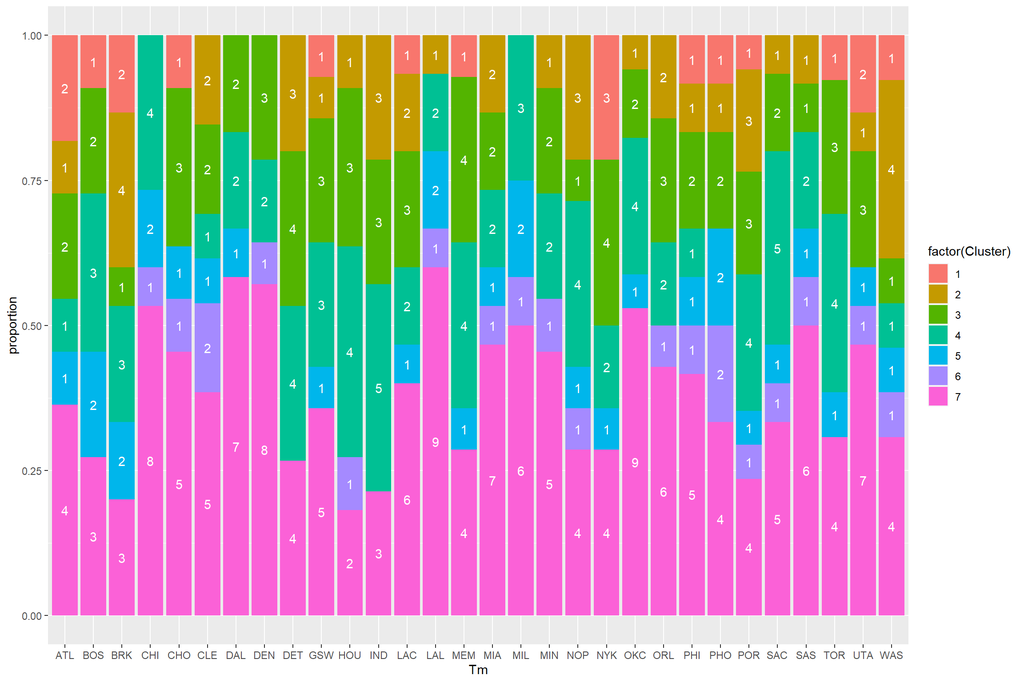

```r
ggplot(data = model_data_clusters2022, aes(x = Tm, fill = factor(Cluster))) +
  geom_bar(position = "fill") + ylab("proportion") +
  stat_count(geom = "text",
             aes(label = stat(count)),
             position=position_fill(vjust=0.5), colour="white")
```

We want to look at teams above .500 and below .500 to see if there are patterns

```r
above500_2022 <- c('PHO','MEM','MIA','GSW','DAL','BOS','MIL','PHI','UTA','TOR','DEN','MIN','CHI','BRK','CLE','ATL','CHO','LAC')
below500_2022 <- c('NYK','NOP','WAS','SAS','LAL','SAC','POR','IND','OKC','DET','ORL','HOU')
```

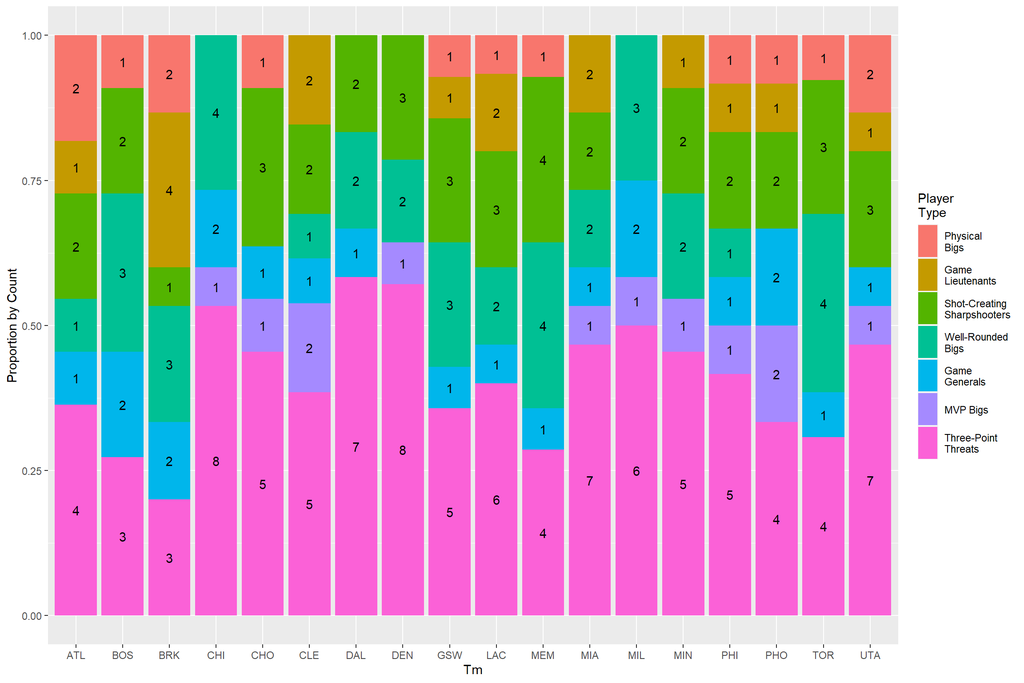

```r
ggplot(data = model_data_clusters2022 %>% filter(Tm %in% above500_2022), aes(x = Tm, fill = factor(Cluster))) +
  geom_bar(position = "fill") + ylab("Proportion by Count") +
  stat_count(geom = "text",
             aes(label = stat(count)),
             position=position_fill(vjust=0.5), colour="Black") +
  scale_fill_discrete(name = "Player\nType", labels =c('Physical\nBigs', 'Game\nLieutenants', 'Shot-Creating\nSharpshooters', 'Well-Rounded\nBigs', 'Game\nGenerals', 'MVP Bigs', 'Three-Point\nThreats')) +
  theme(legend.key.height=unit(1, "cm"))
```

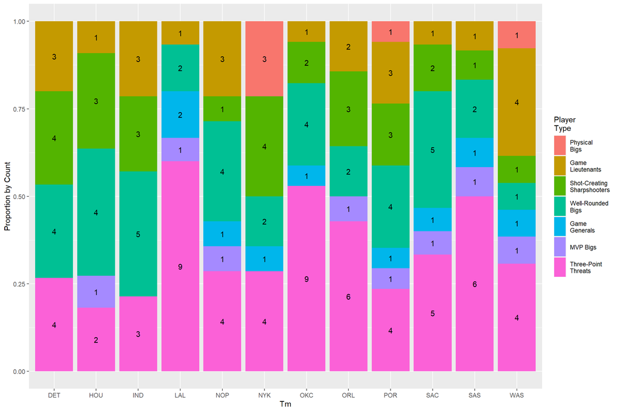

```r
ggplot(data = model_data_clusters2022 %>% filter(Tm %in% below500_2022), aes(x = Tm, fill = factor(Cluster))) +
  geom_bar(position = "fill") + ylab("Proportion by Count") +
  stat_count(geom = "text",
             aes(label = stat(count)),
             position=position_fill(vjust=0.5), colour="Black") +
  scale_fill_discrete(name = "Player\nType", labels =c('Physical\nBigs', 'Game\nLieutenants', 'Shot-Creating\nSharpshooters', 'Well-Rounded\nBigs', 'Game\nGenerals', 'MVP Bigs', 'Three-Point\nThreats')) +
  theme(legend.key.height=unit(1, "cm"))
```

Game Generals and MVP Bigs are by far the most valuable. If we look at the player type history of current Game Generals and MVP Bigs, we see that many of these players developed into this position, rather than always being in this position.

```r
play_list_3 <- c('Bradley Beal','Brandon Ingram','Chris Paul','Damian Lillard','Darius Garland','DeAaron Fox','Dejounte Murray','DeMar DeRozan','Devin Booker','Donovan Mitchell','Ja Morant','James Harden','Jaylen Brown','Jayson Tatum','Jimmy Butler','Jrue Holiday','Julius Randle','Kevin Durant','Khris Middleton','Kyrie Irving','LaMelo Ball','LeBron James','Luka Doncic','Pascal Siakam','Paul George','Russell Westbrook','Shai GilgeousAlexander','Stephen Curry','Trae Young','Zach LaVine'
)

play_list_6 <- c('Anthony Davis','Bam Adebayo','Christian Wood','Deandre Ayton','Domantas Sabonis','Evan Mobley','Giannis Antetokounmpo','Jakob Poeltl','Jarrett Allen','JaVale McGee','Joel Embiid','Jonas Valanciunas','Jusuf Nurkic','KarlAnthony Towns','Kristaps Porzingis','Montrezl Harrell','Nikola Jokic','Nikola Vucevic','Rudy Gobert','Wendell Carter Jr'
)
```

The current Game Generals in the league (30, on the right). The x-axis indicates the year and the bars indicate the count of historical player types for each current Game Generals. A complete player type history for each player can be found in the appendix. Generally speaking, it would appear that Shot-Creating Sharpshooters transition into Game Generals most often (given the frequency of green). A history of each player’s player type is also included.

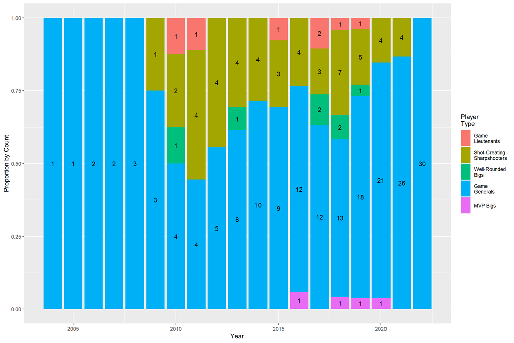

```r
good_players_hist3 <- model_data_clusters1 %>%
  filter(Player %in% play_list_3) %>%
  arrange(Player, desc(Year), Cluster) %>%
  group_by(Player) %>% mutate(count=n())

ggplot(data = good_players_hist3, aes(x = Year, fill = factor(Cluster))) +
  geom_bar(position = "fill") + ylab("Proportion by Count") +
  stat_count(geom = "text",
             aes(label = stat(count)),
             position=position_fill(vjust=0.5), colour="Black") +
  scale_fill_discrete(name = "Player\nType",
                      labels =c('Game\nLieutenants', 'Shot-Creating\nSharpshooters', 'Well-Rounded\nBigs','Game\nGenerals','MVP Bigs')) +
  theme(legend.key.height=unit(1, "cm"))
```

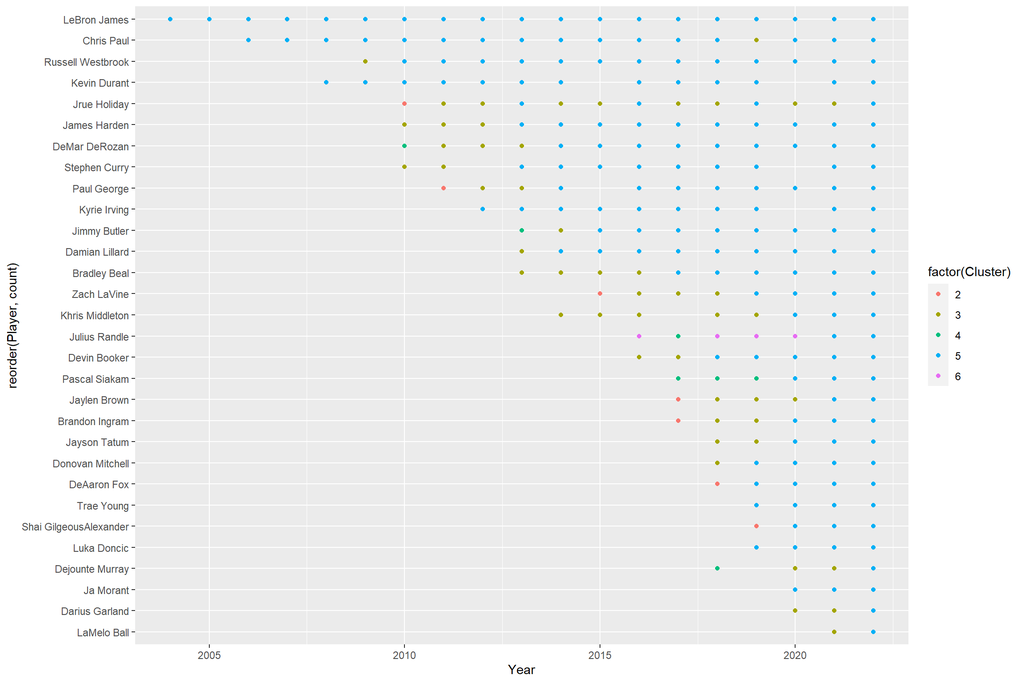

```r
good_players_hist3 %>% arrange(Player, desc(Year), Cluster) %>%
  ggplot(aes(x=Year, y=reorder(Player,count), color = factor(Cluster))) +
  geom_point()
```

The current MVP Bigs in the league (20, on the right). The x-axis indicates the year and the bars indicate the count of historical player types for each current MVP Bigs. A complete player type history for each player can be found in the appendix. Generally speaking, it would appear that Well-Rounded Bigs and Physical Bigs transition into MVP Bigs most often (given the frequency of red and turquoise). A history of each player’s player type is also included.

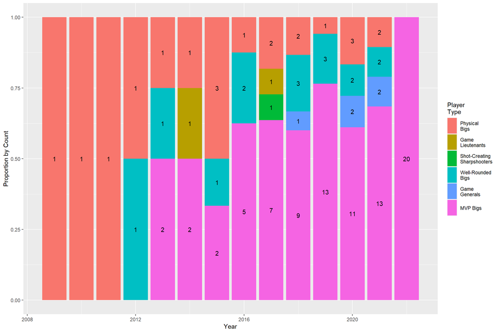

```r
good_players_hist6 <- model_data_clusters1 %>%
  filter(Player %in% play_list_6) %>%
  arrange(Player, desc(Year), Cluster) %>%
  group_by(Player) %>% mutate(count=n())

ggplot(data = good_players_hist6, aes(x = Year, fill = factor(Cluster))) +
  geom_bar(position = "fill") + ylab("Proportion by Count") +
  stat_count(geom = "text",
             aes(label = stat(count)),
             position=position_fill(vjust=0.5), colour="Black") +
  scale_fill_discrete(name = "Player\nType",
                      labels =c('Physical\nBigs', 'Game\nLieutenants', 'Shot-Creating\nSharpshooters', 'Well-Rounded\nBigs', 'Game\nGenerals', 'MVP Bigs')) +
  theme(legend.key.height=unit(1, "cm"))
```

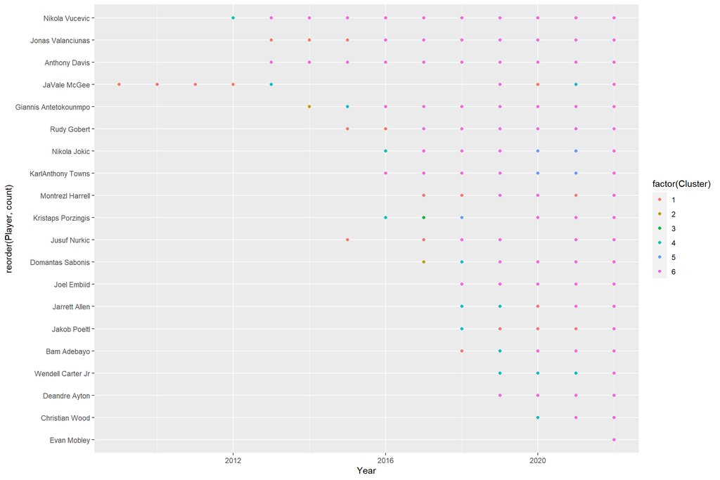

```r
good_players_hist6 %>% arrange(Player, desc(Year), Cluster) %>%
  ggplot(aes(x=Year, y=reorder(Player,count), color = factor(Cluster))) +
  geom_point()
```